# Victoria Integrated Survey of Travel and Activity - Exploratory Data Analysis

Frederick SUBERE-ALBAWY 21960842

2 September 2022

CITS4009 Computational Data Analysis - Project 1

# 1 Introduction

This dataset is from the Victoria State Government Department of Transport. It is survey data from VISTA (Victoria Integrated Survey of Travel and Activity), carried out on 32000 households across Melbourne and Geelong between 2012 and 2018. The VISTA dataset is publicly available online at the following link: https://transport.vic.gov.au/about/data-and-research/vista/vista-data-and-publications The dataset consists of six tables - Household, Person, Stop, Trip, Journey to Work and Journey to Education. Due to the large size of the total data set, for Project 1 we will be focusing our EDA on the stop table.

# 2 Reading data in - First attempt

First we clear all variables and import libraries

```r
rm(list=ls())
```

```r
library(ggplot2)
library(readr)
library(dplyr)
library(gridExtra)
library(knitr)
```

```r
#url <- "https://transport.vic.gov.au/-/media/tfv-documents/vista-12-18-260321.zip?la=en&hash=F39F3E513D07610B1C58A1BD2260FADF"
#tmp <- tempfile()
#download.file(url, tmp, mode="wb")
#stops_file <-unz(tmp, "S_VISTA1218_V1.csv")
#stops <- read.csv(file = stops_file,
#Although project specification says to use initial URL, and above code works in Rstudio, it fails when knitting
setwd("C:/Users/frede/Downloads/VISTA 12-18-260321")
stops <- read.csv(file = "S_VISTA1218_V1.csv",
                 header = TRUE,
                 na.strings = "N/A",
                 comment.char = "",
                 fill = FALSE)

        summary(stops)
```

```
##   ï..STOPID            PERSID              HHID               STOPNO
##  Length:204224      Length:204224      Length:204224      Min.   : 1.000
##  Class :character   Class :character   Class :character   1st Qu.: 2.000
##  Mode  :character   Mode  :character   Mode  :character   Median : 3.000
##                                                           Mean   : 3.384
##                                                           3rd Qu.: 5.000
##                                                           Max.   :26.000
##
##   STARTHOUR            STARTIME         ARRHOUR         ARRTIME
##  Length:204224      Min.   : 128.0   Min.   : 1.00   Min.   : 245.0
##  Class :character   1st Qu.: 570.0   1st Qu.: 9.00   1st Qu.: 585.0
##  Mode  :character   Median : 810.0   Median :13.00   Median : 825.0
##                     Mean   : 801.2   Mean   :13.19   Mean   : 820.2
##                     3rd Qu.:1005.0   3rd Qu.:17.00   3rd Qu.:1022.0
##                     Max.   :1836.0   Max.   :31.00   Max.   :1881.0
##
##     DURATION        DEPHOUR             DEPTIME          TRAVTIME
##  Min.   : -22.0   Length:204224      Min.   : 250.0   Min.   :   0.00
##  1st Qu.:   9.0   Class :character   1st Qu.: 698.0   1st Qu.:   8.00
##  Median :  65.0   Mode  :character   Median : 915.0   Median :  15.00
##  Mean   : 267.1                      Mean   : 874.8   Mean   :  18.95
##  3rd Qu.: 420.0                      3rd Qu.:1040.0   3rd Qu.:  25.00
##  Max.   :1230.0                      Max.   :1836.0   Max.   :1081.00
##  NA's   :17337                       NA's   :49061
##    VISTADIST          ORIGLGA           ORIGPLACE1         ORIGPLACE2
##  Min.   :  -2.000   Length:204224      Length:204224      Length:204224
##  1st Qu.:   1.100   Class :character   Class :character   Class :character
##  Median :   3.200   Mode  :character   Mode  :character   Mode  :character
##  Mean   :   8.964
##  3rd Qu.:   9.200
##  Max.   :9924.000
##
##   ORIGPURP1          ORIGPURP2           DESTLGA           DESTPLACE1
##  Length:204224      Length:204224      Length:204224      Length:204224
##  Class :character   Class :character   Class :character   Class :character
##  Mode  :character   Mode  :character   Mode  :character   Mode  :character
##
##
##
##
```

[output cut: 25 more lines]

```
##  Length:204224      Length:204224      Length:204224      Length:204224
##  Class :character   Class :character   Class :character   Class :character
##  Mode  :character   Mode  :character   Mode  :character   Mode  :character
##
##
##
##
##   WESTOPWGT
##  Length:204224
##  Class :character
##  Mode  :character
##
##
##
##
```

As per the data glossary, the keys are HHID (household id), PERSID (Person id) and STOPID. Each column has a length of 204224 - the data has 204224 rows.

Each row represents a stop - that is, a stage of a trip, made with one mode of transport at a certain time. Walking, then taking a bus, then taking a train, would constitute one trip but three stages hence each would appear as a separate record in this Stop table.

```r
str(stops)
```

```
## 'data.frame':    204224 obs. of  37 variables:
##  $ ï..STOPID : chr  "Y12H0000101P01S01" "Y12H0000101P01S02" "Y12H0000101P02S01" "Y12H0000101P02S02" ...
##  $ PERSID    : chr  "Y12H0000101P01" "Y12H0000101P01" "Y12H0000101P02" "Y12H0000101P02" ...
##  $ HHID      : chr  "Y12H0000101" "Y12H0000101" "Y12H0000101" "Y12H0000101" ...
##  $ STOPNO    : int  1 2 1 2 3 4 5 1 2 1 ...
##  $ STARTHOUR : chr  "8" "17" "8" "9" ...
##  $ STARTIME  : int  525 1050 500 540 600 890 940 500 940 500 ...
##  $ ARRHOUR   : int  9 17 8 9 10 15 15 8 15 8 ...
##  $ ARRTIME   : int  545 1075 520 550 610 910 950 520 950 520 ...
##  $ DURATION  : int  505 NA 20 50 280 30 NA 420 NA 420 ...
##  $ DEPHOUR   : chr  "17" NA "9" "10" ...
##  $ DEPTIME   : int  1050 NA 540 600 890 940 NA 940 NA 940 ...
##  $ TRAVTIME  : int  20 25 20 10 10 20 10 20 10 20 ...
##  $ VISTADIST : num  7.5 7.5 3.9 2.5 2.6 3.9 3.9 3.9 3.9 3.9 ...
##  $ ORIGLGA   : chr  "Whittlesea (C)" "Whittlesea (C)" "Whittlesea (C)" "Whittlesea (C)" ...
```

[output cut: 23 more lines]

There is a reasonable diversity of numerical and categorical data. A few N/A values are visible even in this limited sample around the columns relating to duration and departure time. Also note START_HOUR and DEP_HOUR columns to be read as ‘chr’ type even though the valid duration and time variables appear to be numbers.

We will come back to this and attempt to clean the data after doing one more first look through the head parameter.

```r
head(stops)
```

```
##           ï..STOPID         PERSID        HHID STOPNO STARTHOUR STARTIME
## 1 Y12H0000101P01S01 Y12H0000101P01 Y12H0000101      1         8      525
## 2 Y12H0000101P01S02 Y12H0000101P01 Y12H0000101      2        17     1050
## 3 Y12H0000101P02S01 Y12H0000101P02 Y12H0000101      1         8      500
## 4 Y12H0000101P02S02 Y12H0000101P02 Y12H0000101      2         9      540
## 5 Y12H0000101P02S03 Y12H0000101P02 Y12H0000101      3        10      600
## 6 Y12H0000101P02S04 Y12H0000101P02 Y12H0000101      4        14      890
##   ARRHOUR ARRTIME DURATION DEPHOUR DEPTIME TRAVTIME VISTADIST        ORIGLGA
## 1       9     545      505      17    1050       20       7.5 Whittlesea (C)
## 2      17    1075       NA    <NA>      NA       25       7.5 Whittlesea (C)
## 3       8     520       20       9     540       20       3.9 Whittlesea (C)
## 4       9     550       50      10     600       10       2.5 Whittlesea (C)
## 5      10     610      280      14     890       10       2.6 Whittlesea (C)
## 6      15     910       30      15     940       20       3.9 Whittlesea (C)
##           ORIGPLACE1      ORIGPLACE2                   ORIGPURP1
```

[output cut: 55 more lines]

There are 37 different columns. The higher up you go in the person number columns, the less likely there seems to be an additional person present. It may be worth exploring if say PERSON9 ever bears a ‘Yes - present for trip’ value.

## 2.1 Investigating hour column values

Looking into START_HOUR:

```r
levels(factor(stops$STARTHOUR))
```

```
##  [1] "1"          "10"         "11"         "12"         "13"
##  [6] "14"         "15"         "16"         "17"         "18"
## [11] "19"         "2"          "20"         "21"         "22"
## [16] "23"         "24"         "25"         "26"         "27"
## [21] "28"         "3"          "30"         "4"          "5"
## [26] "6"          "7"          "8"          "9"          "Not Stated"
```

From the START_HOUR duration it is clear that the ‘Not Stated’ value is causing the column to be read as ‘chr’, though all other values are numerical.

```r
levels(factor(stops$DEPHOUR))
```

```
##  [1] "1"          "10"         "11"         "12"         "13"
##  [6] "14"         "15"         "16"         "17"         "18"
## [11] "19"         "2"          "20"         "21"         "22"
## [16] "23"         "24"         "25"         "26"         "27"
## [21] "28"         "3"          "30"         "4"          "5"
## [26] "6"          "7"          "8"          "9"          "Not Stated"
```

And the same about the ‘Not Stated’ value applies to DEP_HOUR

The fact that the hour values go up to 30 is unexpected and at first glance these values may be invalid, as hours should only go up to 24. However the data glossary makes mention of a “27 hour-day”. A likely interpretation of this, particularly in the transportation and activity context, is that hours greater than 24 refer to times that are after midnight but still conceptualised as part of the previous day. For instance many bus and train timetables show a service at say 1am at the end of the day’s schedule (technically the previous day), not the beginning of the day to which it technically belongs. Also in day to day life people tend to see 1am not as the start of a new day but as late in the previous day. This notation is also used on signs in Japan (https://www.reddit.com/r/LearnJapanese/comments/712jym/is_it_normal_in_japan_that_time_goes_beyond_the/, https://www.reddit.com/r/Military/comments/2vo81n/im_new_to_military_time_but_2500/)

However, the existence of levels both 25 to 30 and 1 to 6 implies overlap that may be unhelpful in retrieving all the travel that occurred at a certain time of day.

In respect of this it may be useful to subtract 24 from hour values over 24 as part of the data processing. The task that must be done first, however, is to account for ‘Not Stated’ and convert all other values to numerical.

The easiest way to deal with this may have been to add ‘Not Stated’ to na.strings. Redoing:

# 3 Reading data - once more with clarity

```r
#url <- "https://transport.vic.gov.au/-/media/tfv-documents/vista-12-18-260321.zip?la=en&hash=F39F3E513D07610B1C58A1BD2260FADF"
#tmp <- tempfile()
#download.file(url, tmp, mode="wb")
#stops_file <-unz(tmp, "S_VISTA1218_V1.csv")
#stops <- read.csv(file = stops_file,
setwd("C:/Users/frede/Downloads/VISTA 12-18-260321")
stops <- read.csv(file = "S_VISTA1218_V1.csv",
                 header = TRUE,
                 na.strings = c("N/A","Not Stated"),
                 comment.char = "",
                 fill = FALSE)

        summary(stops)
```

```
##   ï..STOPID            PERSID              HHID               STOPNO
##  Length:204224      Length:204224      Length:204224      Min.   : 1.000
##  Class :character   Class :character   Class :character   1st Qu.: 2.000
##  Mode  :character   Mode  :character   Mode  :character   Median : 3.000
##                                                           Mean   : 3.384
##                                                           3rd Qu.: 5.000
##                                                           Max.   :26.000
##
##    STARTHOUR        STARTIME         ARRHOUR         ARRTIME
##  Min.   : 1.00   Min.   : 128.0   Min.   : 1.00   Min.   : 245.0
##  1st Qu.: 9.00   1st Qu.: 570.0   1st Qu.: 9.00   1st Qu.: 585.0
##  Median :13.00   Median : 810.0   Median :13.00   Median : 825.0
##  Mean   :12.93   Mean   : 801.2   Mean   :13.19   Mean   : 820.2
##  3rd Qu.:16.00   3rd Qu.:1005.0   3rd Qu.:17.00   3rd Qu.:1022.0
##  Max.   :30.00   Max.   :1836.0   Max.   :31.00   Max.   :1881.0
##  NA's   :1
##     DURATION         DEPHOUR         DEPTIME          TRAVTIME
##  Min.   : -22.0   Min.   : 1.00   Min.   : 250.0   Min.   :   0.00
##  1st Qu.:   9.0   1st Qu.:11.00   1st Qu.: 698.0   1st Qu.:   8.00
##  Median :  65.0   Median :15.00   Median : 915.0   Median :  15.00
##  Mean   : 267.1   Mean   :14.11   Mean   : 874.8   Mean   :  18.95
##  3rd Qu.: 420.0   3rd Qu.:17.00   3rd Qu.:1040.0   3rd Qu.:  25.00
##  Max.   :1230.0   Max.   :30.00   Max.   :1836.0   Max.   :1081.00
##  NA's   :17337    NA's   :49010   NA's   :49061
##    VISTADIST          ORIGLGA           ORIGPLACE1         ORIGPLACE2
##  Min.   :  -2.000   Length:204224      Length:204224      Length:204224
##  1st Qu.:   1.100   Class :character   Class :character   Class :character
##  Median :   3.200   Mode  :character   Mode  :character   Mode  :character
##  Mean   :   8.964
##  3rd Qu.:   9.200
##  Max.   :9924.000
##
##   ORIGPURP1          ORIGPURP2           DESTLGA           DESTPLACE1
##  Length:204224      Length:204224      Length:204224      Length:204224
##  Class :character   Class :character   Class :character   Class :character
##  Mode  :character   Mode  :character   Mode  :character   Mode  :character
##
##
##
##
```

[output cut: 25 more lines]

```
##  Length:204224      Length:204224      Length:204224      Length:204224
##  Class :character   Class :character   Class :character   Class :character
##  Mode  :character   Mode  :character   Mode  :character   Mode  :character
##
##
##
##
##   WESTOPWGT
##  Length:204224
##  Class :character
##  Mode  :character
##
##
##
##
```

This seems to deal with DEPHOUR and STARTHOUR

# 4 Data cleaning

## 4.1 Dealing with 30-hour time

Before cleaning up the hours greater than 30, it may be interesting to plot a histogram to show the raw distribution.

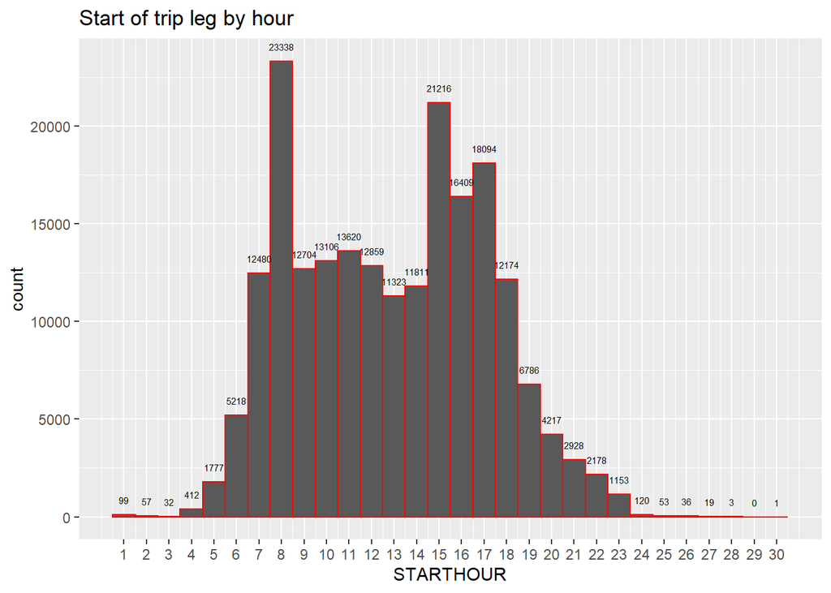

```r
plot_hist = function(x_var,bins){
  ggplot(stops, aes(x=x_var))+geom_histogram(bins = bins, col=I("red"))+stat_bin(geom='text',aes(label=..count..),size=2,vjust=-1.5, bins = bins)
}
plot_hist(stops$STARTHOUR,30)+scale_x_continuous(breaks=c(1:30))+labs(x="STARTHOUR",title="Start of trip leg by hour")
```

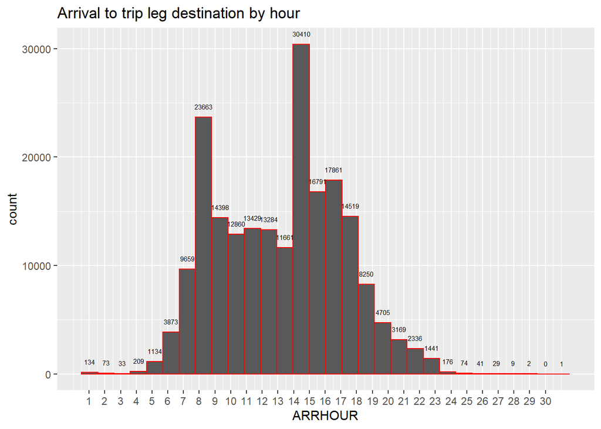

```r
plot_hist(stops$ARRHOUR,30)+scale_x_continuous(breaks=c(1:30))+labs(x="ARRHOUR",title="Arrival to trip leg destination by hour")
```

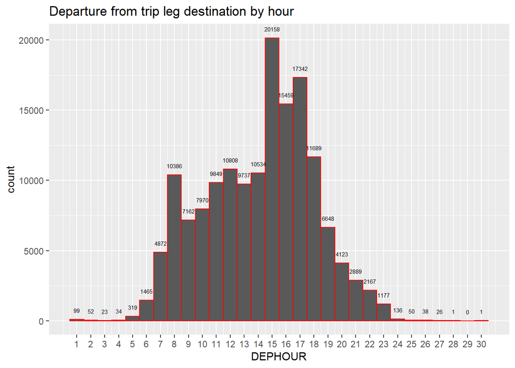

```r
plot_hist(stops$DEPHOUR,30)+scale_x_continuous(breaks=c(1:30))+labs(x="DEPHOUR",title="Departure from trip leg destination by hour")
```

The values 1 to 6 seem to mostly be larger than the corresponding values 24 to 30. So it makes a lot of sense to consolidate these values in the 1 to 6 range.

It is worth noting though that the 30-hr clock does carry some useful information about the relationships between times - eg. a departure at hour 25 is mathematically after an arrival at 23 in a way that a departure at 1 cannot be easily shown to be. So there may be value in adding transformed columns but keeping the original columns for reference. (Due to the large size of the dataset, over 100MB, and my limited RAM, I will avoid maintaining multiple copies of the data)

```r
convert30to24hrtime = function(column){
  column <- ifelse(column > 24, column-24, column)
  factor(column)
  return(column)
}

stops$ARRHOUR_24 <- convert30to24hrtime(stops$ARRHOUR)
stops$STARTHOUR_24 <- convert30to24hrtime(stops$STARTHOUR)
stops$DEPHOUR_24 <- convert30to24hrtime(stops$DEPHOUR)
```

## 4.2 Are all 9 person columns used?

The next order of business is to answer the question of whether the higher number PERSON columns have any values other than No

```r
table(stops$PERSON9)
```

```
##
##   No - not present for trip No such person in household
##                         255                      203876
##      Yes - present for trip
##                          93
```

So it seems there are 93 trips where a ninth person is present. It stands to reason that an PERSONs 1 to 8 will also be present. It turns out all the columns are there for a reason.

## 4.3 Minutes columns

To refresh our understanding of the data after the above transformations:

```r
summary(stops)
```

```
##   ï..STOPID            PERSID              HHID               STOPNO
##  Length:204224      Length:204224      Length:204224      Min.   : 1.000
##  Class :character   Class :character   Class :character   1st Qu.: 2.000
##  Mode  :character   Mode  :character   Mode  :character   Median : 3.000
##                                                           Mean   : 3.384
##                                                           3rd Qu.: 5.000
##                                                           Max.   :26.000
##
##    STARTHOUR        STARTIME         ARRHOUR         ARRTIME
##  Min.   : 1.00   Min.   : 128.0   Min.   : 1.00   Min.   : 245.0
##  1st Qu.: 9.00   1st Qu.: 570.0   1st Qu.: 9.00   1st Qu.: 585.0
##  Median :13.00   Median : 810.0   Median :13.00   Median : 825.0
##  Mean   :12.93   Mean   : 801.2   Mean   :13.19   Mean   : 820.2
##  3rd Qu.:16.00   3rd Qu.:1005.0   3rd Qu.:17.00   3rd Qu.:1022.0
##  Max.   :30.00   Max.   :1836.0   Max.   :31.00   Max.   :1881.0
##  NA's   :1
##     DURATION         DEPHOUR         DEPTIME          TRAVTIME
##  Min.   : -22.0   Min.   : 1.00   Min.   : 250.0   Min.   :   0.00
##  1st Qu.:   9.0   1st Qu.:11.00   1st Qu.: 698.0   1st Qu.:   8.00
##  Median :  65.0   Median :15.00   Median : 915.0   Median :  15.00
##  Mean   : 267.1   Mean   :14.11   Mean   : 874.8   Mean   :  18.95
##  3rd Qu.: 420.0   3rd Qu.:17.00   3rd Qu.:1040.0   3rd Qu.:  25.00
##  Max.   :1230.0   Max.   :30.00   Max.   :1836.0   Max.   :1081.00
##  NA's   :17337    NA's   :49010   NA's   :49061
##    VISTADIST          ORIGLGA           ORIGPLACE1         ORIGPLACE2
##  Min.   :  -2.000   Length:204224      Length:204224      Length:204224
##  1st Qu.:   1.100   Class :character   Class :character   Class :character
##  Median :   3.200   Mode  :character   Mode  :character   Mode  :character
##  Mean   :   8.964
##  3rd Qu.:   9.200
##  Max.   :9924.000
##
##   ORIGPURP1          ORIGPURP2           DESTLGA           DESTPLACE1
##  Length:204224      Length:204224      Length:204224      Length:204224
##  Class :character   Class :character   Class :character   Class :character
##  Mode  :character   Mode  :character   Mode  :character   Mode  :character
##
##
##
##
```

[output cut: 25 more lines]

```
##  Length:204224      Length:204224      Length:204224      Length:204224
##  Class :character   Class :character   Class :character   Class :character
##  Mode  :character   Mode  :character   Mode  :character   Mode  :character
##
##
##
##
##   WESTOPWGT           ARRHOUR_24     STARTHOUR_24     DEPHOUR_24
##  Length:204224      Min.   : 1.00   Min.   : 1.00   Min.   : 1.00
##  Class :character   1st Qu.: 9.00   1st Qu.: 9.00   1st Qu.:11.00
##  Mode  :character   Median :13.00   Median :13.00   Median :15.00
##                     Mean   :13.17   Mean   :12.92   Mean   :14.09
##                     3rd Qu.:17.00   3rd Qu.:16.00   3rd Qu.:17.00
##                     Max.   :24.00   Max.   :24.00   Max.   :24.00
##                                     NA's   :1       NA's   :49010
```

According to the data glossary, the columns STARTIME, ARRTIME and DEPTIME represent time in minutes from midnight (of starting trip stage, ending trip stage, and departing from stop location respectively).

```r
convert30to24timeminutes = function(column){
  column <- ifelse(column > 1440, column-1440, column)
  factor(column)
  return(column)
}

stops$ARRTIME_1440 <- convert30to24hrtime(stops$ARRTIME)
stops$STARTIME_1440 <- convert30to24hrtime(stops$STARTIME)
stops$DEPTIME_1440 <- convert30to24hrtime(stops$DEPTIME)
```

## 4.4 Trip weights

The final two columns, WDSTOPWGT and WESTOPWGT seem to be parsed as characters. Yet they are largely numerical values.

The data glossary states: * ‘Stop weight for an ’Average weekday’ of the combined 2012-18 dataset, using the ASGC.’ * ‘Stop weight for an ’Average weekend day’ of the combined 2012-18 dataset, using the ASGC.’

Hence it appears they represent weighting of trips based on how closely demographics of persons making these trips represent the total demographics of the statistical area (ASGC stands for Australian Standard Geographical Classification).

```r
head(table(stops$WDSTOPWGT))
```

```
##
##          1,007.88 1,117.44 1,166.12 1,180.01 1,181.32
##    44849        8        2        2       12        6
```

```r
head(table(stops$WESTOPWGT))
```

```
##
##          1,000.51 1,007.33 1,010.96 1,020.24 1,026.95
##   159375       15        6        2        8        6
```

It is apparent that there are some values above 1000. These are represented with a ‘,’ for thousands and alphabetical sorting shows them before values in the 100s range. It appears that R is not parsing numbers with a comma correctly.

There is a function called parse_number in the Readr library.

```r
stops$WDSTOPWGT <- parse_number(stops$WDSTOPWGT)
stops$WESTOPWGT <- parse_number(stops$WESTOPWGT)
```

```r
summary(stops)
```

```
##   ï..STOPID            PERSID              HHID               STOPNO
##  Length:204224      Length:204224      Length:204224      Min.   : 1.000
##  Class :character   Class :character   Class :character   1st Qu.: 2.000
##  Mode  :character   Mode  :character   Mode  :character   Median : 3.000
##                                                           Mean   : 3.384
##                                                           3rd Qu.: 5.000
##                                                           Max.   :26.000
##
##    STARTHOUR        STARTIME         ARRHOUR         ARRTIME
##  Min.   : 1.00   Min.   : 128.0   Min.   : 1.00   Min.   : 245.0
##  1st Qu.: 9.00   1st Qu.: 570.0   1st Qu.: 9.00   1st Qu.: 585.0
##  Median :13.00   Median : 810.0   Median :13.00   Median : 825.0
##  Mean   :12.93   Mean   : 801.2   Mean   :13.19   Mean   : 820.2
##  3rd Qu.:16.00   3rd Qu.:1005.0   3rd Qu.:17.00   3rd Qu.:1022.0
##  Max.   :30.00   Max.   :1836.0   Max.   :31.00   Max.   :1881.0
##  NA's   :1
##     DURATION         DEPHOUR         DEPTIME          TRAVTIME
##  Min.   : -22.0   Min.   : 1.00   Min.   : 250.0   Min.   :   0.00
##  1st Qu.:   9.0   1st Qu.:11.00   1st Qu.: 698.0   1st Qu.:   8.00
##  Median :  65.0   Median :15.00   Median : 915.0   Median :  15.00
##  Mean   : 267.1   Mean   :14.11   Mean   : 874.8   Mean   :  18.95
##  3rd Qu.: 420.0   3rd Qu.:17.00   3rd Qu.:1040.0   3rd Qu.:  25.00
##  Max.   :1230.0   Max.   :30.00   Max.   :1836.0   Max.   :1081.00
##  NA's   :17337    NA's   :49010   NA's   :49061
##    VISTADIST          ORIGLGA           ORIGPLACE1         ORIGPLACE2
##  Min.   :  -2.000   Length:204224      Length:204224      Length:204224
##  1st Qu.:   1.100   Class :character   Class :character   Class :character
##  Median :   3.200   Mode  :character   Mode  :character   Mode  :character
##  Mean   :   8.964
##  3rd Qu.:   9.200
##  Max.   :9924.000
##
##   ORIGPURP1          ORIGPURP2           DESTLGA           DESTPLACE1
##  Length:204224      Length:204224      Length:204224      Length:204224
##  Class :character   Class :character   Class :character   Class :character
##  Mode  :character   Mode  :character   Mode  :character   Mode  :character
##
##
##
##
```

[output cut: 33 more lines]

```
##  Min.   :   62.92   Min.   : 1.00   Min.   : 1.00   Min.   : 1.00
##  1st Qu.:  213.84   1st Qu.: 9.00   1st Qu.: 9.00   1st Qu.:11.00
##  Median :  283.76   Median :13.00   Median :13.00   Median :15.00
##  Mean   :  327.87   Mean   :13.17   Mean   :12.92   Mean   :14.09
##  3rd Qu.:  380.88   3rd Qu.:17.00   3rd Qu.:16.00   3rd Qu.:17.00
##  Max.   :10369.51   Max.   :24.00   Max.   :24.00   Max.   :24.00
##  NA's   :159375                     NA's   :1       NA's   :49010
##   ARRTIME_1440    STARTIME_1440     DEPTIME_1440
##  Min.   : 221.0   Min.   : 104.0   Min.   : 226.0
##  1st Qu.: 561.0   1st Qu.: 546.0   1st Qu.: 674.0
##  Median : 801.0   Median : 786.0   Median : 891.0
##  Mean   : 796.2   Mean   : 777.2   Mean   : 850.8
##  3rd Qu.: 998.0   3rd Qu.: 981.0   3rd Qu.:1016.0
##  Max.   :1857.0   Max.   :1812.0   Max.   :1812.0
##                                    NA's   :49061
```

WDSTOPWGT and WESTOPWGT are now correctly parsed as this numbers.

## 4.5 Other extreme values

It may also be interesting to look at other extreme values such as for VISTADIST, TRAVTIME, DURATION and STOPNO

## 4.6 DURATION cleanup and extreme values

A clarification first, referring to the data glossary to distinguish between the similar sounding TRAVTIME and DURATION, DURATION refers to the duration of the activity at the stop, not the duration of travel time as in TRAV TIME.

```r
summary(stops$DURATION)
```

```
##    Min. 1st Qu.  Median    Mean 3rd Qu.    Max.    NA's
##   -22.0     9.0    65.0   267.1   420.0  1230.0   17337
```

The minimum activity duration is -22. A negative value does not really make sense, it will have to be regarded as an invalid value and cleaned.

But before removing negative values it would be interesting to see how many there are and what other corresponding column values are.

```r
count.neg <- sum(stops$DURATION < 0, na.rm = TRUE)
cat("Negative values:",count.neg)
```

```
## Negative values: 6
```

```r
count.zero <- sum(stops$DURATION == 0, na.rm = TRUE)
cat("\nZero values:",count.zero)
```

```
##
## Zero values: 22919
```

There are only 6 negative values. There are many zero values, but this is quite normal, as someone may for example get off a train and immediately start the next walking leg of their trip.

Inspecting the six values, each has an ARRTIME after the DEPTIME. In these cases the mathematical relationship of duration as the time from arrival to departure is consistent. It is possible that there may be a data entry error, such as a confusion of the two fields. It may be an idea to keep these rows and swap around arrival and departure, but we can’t be too sure exactly what happened. It may be simpler to just delete these rows, given several columns have invalid data.

```r
stops[!is.na(stops$DURATION)&stops$DURATION<0,]%>% select("STARTHOUR":"VISTADIST")
```

```
##        STARTHOUR STARTIME ARRHOUR ARRTIME DURATION DEPHOUR DEPTIME TRAVTIME
## 151212        10      600      10     605       -5      10     600        5
## 152765        12      755      12     777      -22      13     755       22
## 152766        12      755      13     785       -5      13     780       30
## 152771        12      755      12     777      -22      13     755       22
## 152772        12      755      13     785       -5      13     780       30
## 157324        15      951      15     958       -6      15     952        7
##        VISTADIST
## 151212       1.0
## 152765       1.0
## 152766      23.9
## 152771       1.0
## 152772      23.9
## 157324       4.0
```

```r
stops <- stops[stops$DURATION >= 0,]
```

## 4.7 VISTADIST cleanup and extreme values

We will cleanup and explore VISTADIST. Distance should also have some relationship to TRAVTIME

```r
summary(stops$VISTADIST)
```

```
##     Min.  1st Qu.   Median     Mean  3rd Qu.     Max.     NA's
##   -2.000    1.100    3.200    8.898    9.100 9924.000    17337
```

A negative distance doesn’t make sense and should be considered invalid.

A maximum distance of 9924 is surprising, it is a far longer distance than anything possible within Victoria or the entirety of Australia. It is likely to be an overseas trip. It may be worth clarifying with the data collectors if overseas trips are in scope, but we cannot say categorically that it is invalid.

```r
count.neg <- sum(stops$VISTADIST < 0, na.rm = TRUE)
cat("Negative distance travel:",count.neg, "or ", count.neg/length(stops$VISTADIST)*100,"%")
```

```
## Negative distance travel: 1 or  0.0004896728 %
```

There is only one case of negative distance travel.

```r
count.zero <- sum(stops$VISTADIST == 0, na.rm = TRUE)
cat("\nZero distance travel:",count.zero, "or ", count.zero/length(stops$VISTADIST)*100,"%")
```

```
##
## Zero distance travel: 1681 or  0.82314 %
```

There is a lot of zero distance travel (still less than 1% of total), which is expected as many stages (mostly walking) would be quite short.

```r
count.over <- sum(stops$VISTADIST > 1000, na.rm = TRUE)
cat("\nTravel over 1000km:",count.over, "or ", count.over/length(stops$VISTADIST)*100,"%")
```

```
##
## Travel over 1000km: 31 or  0.01517986 %
```

There are still 31 trips over 1000km, a distance far longer than even the distance from Melbourne to Sydney or Adelaide. So there are a significant number of overseas or long interstate flights (possibly road trips depending on time) in the dataset.

```r
stops[stops$VISTADIST < 0&!is.na(stops$VISTADIST),]%>% select("STARTHOUR":"VISTADIST")
```

```
##        STARTHOUR STARTIME ARRHOUR ARRTIME DURATION DEPHOUR DEPTIME TRAVTIME
## 185228        20     1432      25    1552      999      23      NA      120
##        VISTADIST
## 185228        -2
```

It is not clear why this is a -2. The deptime is missing as well. It would be worthwhile to remove this record.

```r
stops <- stops[stops$VISTADIST >= 0,]
```

```r
stops[stops$VISTADIST > 2500 & !is.na(stops$VISTADIST),]%>% select("STARTHOUR":"Mode_grp4")
```

```
##        STARTHOUR STARTIME ARRHOUR ARRTIME DURATION DEPHOUR DEPTIME TRAVTIME
## 156226         4      240       9     578       82      11     660      338
## 158834         4      240      15     945       25      16     970      705
## 158836         4      240       6     380       51       7     431      140
## 172965         4      240      19    1140       60      20    1200      900
## 190417         4      240      22    1321       64      23    1385     1081
## 197297         4      240      19    1155       60      20    1215      915
##        VISTADIST ORIGLGA ORIGPLACE1 ORIGPLACE2
## 156226    9924.0              Other  Other NEC
## 158834    9924.0              Other  Other NEC
## 158836    9924.0              Other  Other NEC
## 172965    9924.0              Other  Other NEC
## 190417    9924.0              Other  Other NEC
## 197297    9923.7              Other  Other NEC
##                                ORIGPURP1                 ORIGPURP2  DESTLGA
```

[output cut: 20 more lines]

Examining the very longest stages, these all cover a distance of around 9924 km, although travel time varies widely from 140 to 1081.

Ultimately, it would be useful to clean out data which shows speeds that are implausibly high. However whether a speed is too high can depend on the mode, and some calls can be quite subjective.

## 4.8 NA Values

Something noticeable but not mentioned in some of the table extracts above is a very proportion of NAs. For some records, it seems that every column is NA. It would be interesting to see for how many records this is the case.

```r
nrow(stops[rowSums(is.na(stops)) == ncol(stops), ])
```

```
## [1] 17337
```

There are 17,337 such rows! They should all be dropped.

```r
stops <- stops[rowSums(is.na(stops)) != ncol(stops), ]
```

```r
count_na = function(stops) {
    sapply(stops, FUN = function(col) sum(is.na(col)) )
}
na.counts <- count_na(stops)
na.counts
```

```
##     ï..STOPID        PERSID          HHID        STOPNO     STARTHOUR
##             0             0             0             0             1
##      STARTIME       ARRHOUR       ARRTIME      DURATION       DEPHOUR
##             0             0             0             0         31673
##       DEPTIME      TRAVTIME     VISTADIST       ORIGLGA    ORIGPLACE1
##         31723             0             0             0             1
##    ORIGPLACE2     ORIGPURP1     ORIGPURP2       DESTLGA    DESTPLACE1
##             0             4             0             0             1
##    DESTPLACE2     DESTPURP1     DESTPURP2      FULLMODE      MAINMODE
##             0             4             0             0             0
##     Mode_grp4       PERSON1       PERSON2       PERSON3       PERSON4
##             0             0             0             0             0
##       PERSON5       PERSON6       PERSON7       PERSON8       PERSON9
##             0             0             0             0             0
##     WDSTOPWGT     WESTOPWGT    ARRHOUR_24  STARTHOUR_24    DEPHOUR_24
##         40696        146184             0             1         31673
##  ARRTIME_1440 STARTIME_1440  DEPTIME_1440
##             0             0         31723
```

Here we can see that most columns now have zero or very few NAs.

The columns with significant NAs are DEPHOUR, DEPTIME, WDSTOPWGT and WESTOPWGT.

WDSTOPWGT and WESTOPWGT are a peculiar case because they represent the same concept (trip weighting) but on weekdays and weekends, so they appear to be mutually exclusive. This will be confirmed below:

```r
stops[is.na(stops$WDSTOPWGT)&is.na(stops$WESTOPWGT),]
```

```
##  [1] ï..STOPID     PERSID        HHID          STOPNO        STARTHOUR
##  [6] STARTIME      ARRHOUR       ARRTIME       DURATION      DEPHOUR
## [11] DEPTIME       TRAVTIME      VISTADIST     ORIGLGA       ORIGPLACE1
## [16] ORIGPLACE2    ORIGPURP1     ORIGPURP2     DESTLGA       DESTPLACE1
## [21] DESTPLACE2    DESTPURP1     DESTPURP2     FULLMODE      MAINMODE
## [26] Mode_grp4     PERSON1       PERSON2       PERSON3       PERSON4
## [31] PERSON5       PERSON6       PERSON7       PERSON8       PERSON9
## [36] WDSTOPWGT     WESTOPWGT     ARRHOUR_24    STARTHOUR_24  DEPHOUR_24
## [41] ARRTIME_1440  STARTIME_1440 DEPTIME_1440
## <0 rows> (or 0-length row.names)
```

```r
stops[!is.na(stops$WDSTOPWGT)&!is.na(stops$WESTOPWGT),]
```

```
##  [1] ï..STOPID     PERSID        HHID          STOPNO        STARTHOUR
##  [6] STARTIME      ARRHOUR       ARRTIME       DURATION      DEPHOUR
## [11] DEPTIME       TRAVTIME      VISTADIST     ORIGLGA       ORIGPLACE1
## [16] ORIGPLACE2    ORIGPURP1     ORIGPURP2     DESTLGA       DESTPLACE1
## [21] DESTPLACE2    DESTPURP1     DESTPURP2     FULLMODE      MAINMODE
## [26] Mode_grp4     PERSON1       PERSON2       PERSON3       PERSON4
## [31] PERSON5       PERSON6       PERSON7       PERSON8       PERSON9
## [36] WDSTOPWGT     WESTOPWGT     ARRHOUR_24    STARTHOUR_24  DEPHOUR_24
## [41] ARRTIME_1440  STARTIME_1440 DEPTIME_1440
## <0 rows> (or 0-length row.names)
```

There are no rows where neither or indeed both of the columns are NA. So there are no actual missing values.

DEPHOUR has 31673 NAs and DEPTIME has 31723 NAs. It would be interesting to see if DEPHOUR NAs are a subset of DEPTIME NAs

```r
stops[is.na(stops$DEPHOUR)&!is.na(stops$DEPTIME),]%>% select("STARTHOUR":"VISTADIST")
```

```
##       STARTHOUR STARTIME ARRHOUR ARRTIME DURATION DEPHOUR DEPTIME TRAVTIME
## 46552         4      240       4     256        0      NA     256       16
##       VISTADIST
## 46552       1.3
```

There is only one NA DEPHOUR with a populated DEPTIME. In this instance, the DEPHOUR can be imputed from the DEPTIME.

```r
stops[is.na(stops$DEPHOUR)&!is.na(stops$DEPTIME),]$DEPHOUR <- stops[is.na(stops$DEPHOUR)&!is.na(stops$DEPTIME),]$DEPTIME%/%60
stops[stops$ï..STOPID=='Y13H0680128P04S01',] %>% select(DEPTIME,DEPHOUR)
```

```
##       DEPTIME DEPHOUR
## 46552     256       4
```

```r
select(stops[!is.na(stops$DEPHOUR)&is.na(stops$DEPTIME),],DEPHOUR,DEPTIME,DURATION)
```

```
##        DEPHOUR DEPTIME DURATION
## 149954      22      NA      999
## 151143      27      NA      999
## 151416      23      NA      999
## 151597      24      NA      999
## 154004      23      NA      999
## 155001      23      NA      999
## 157844      24      NA      999
## 157907      24      NA      999
## 157918      24      NA      999
## 159992      23      NA      999
## 160424      21      NA      999
## 161180      19      NA      999
## 161479      23      NA      999
## 162310      23      NA      999
```

[output cut: 37 more lines]

In principle it would be possible to impute the deptime from the sum of the arrtime and duration, or estimate it from the dephour. However, the duration for every record in this set is 999, and it would be very odd if this diverse set of records all happened to have the same duration of 999. Adding this duration would also not produce a dephour corresponding to the deptime. This suggests issues with the quality of the data collected. Hence it may be worthwhile to simply drop these rows. But we should investigate the cases of both DEPHOUR and DEPTIME being NA before actioning anything.

```r
select(head(stops[is.na(stops$DEPHOUR)&is.na(stops$DEPTIME),]),DEPHOUR,DEPTIME,DURATION)
```

```
##       DEPHOUR DEPTIME DURATION
## 35612      NA      NA      999
## 35614      NA      NA      999
## 35615      NA      NA      999
## 35617      NA      NA      999
## 35619      NA      NA      999
## 35621      NA      NA      999
```

Many of these values also contain a duration of 999. Let’s see if there are any that do not:

```r
stops[is.na(stops$DEPTIME)&stops$DURATION!=999,]%>% select("STARTHOUR":"VISTADIST")
```

```
##       STARTHOUR STARTIME ARRHOUR ARRTIME DURATION DEPHOUR DEPTIME TRAVTIME
## 42897        13      810      14     840      175      NA      NA       30
## 46402        11      675      11     680      100      NA      NA        5
##       VISTADIST
## 42897       4.5
## 46402       0.8
```

```r
nrow(stops[is.na(stops$DEPTIME)&stops$DURATION==999,])
```

```
## [1] 31721
```

```r
nrow(stops[!is.na(stops$DEPTIME)&stops$DURATION==999,])
```

```
## [1] 18
```

There are 31721 records with missing DEPTIME bearing the DURATION 999, but only 18 records with DEPTIME bearing DURATION 999 (which is within a reasonable distribution). 31721 records may be too much to drop entirely from the dataset. It may be more reasonable in this instance to set the duration to NA, or simply bear in mind that there seems to be some systematic error in the duration and investigate further. Turning to STARTHOUR

```r
stops[is.na(stops$STARTHOUR),]%>% select("STARTHOUR":"VISTADIST")
```

```
##       STARTHOUR STARTIME ARRHOUR ARRTIME DURATION DEPHOUR DEPTIME TRAVTIME
## 38161        NA     1360      23    1380       20      23    1400       20
##       VISTADIST
## 38161       9.4
```

In the case of STARTHOUR, it can be imputed from the STARTTIME as in the DEPHOUR case above:

```r
stops[is.na(stops$STARTHOUR),]$STARTHOUR <- stops[is.na(stops$STARTHOUR),]$STARTIME%/%60
stops[is.na(stops$STARTHOUR_24),]$STARTHOUR_24 <- stops[is.na(stops$STARTHOUR_24),]$STARTIME%/%60
stops[stops$ï..STOPID=='Y13H0560438P04S10',]
```

```
##               ï..STOPID         PERSID        HHID STOPNO STARTHOUR STARTIME
## 38161 Y13H0560438P04S10 Y13H0560438P04 Y13H0560438     10        22     1360
##       ARRHOUR ARRTIME DURATION DEPHOUR DEPTIME TRAVTIME VISTADIST     ORIGLGA
## 38161      23    1380       20      23    1400       20       9.4 Darebin (C)
##              ORIGPLACE1    ORIGPLACE2   ORIGPURP1        ORIGPURP2
## 38161 Transport Feature Train Station Change Mode Got on or off PT
##             DESTLGA        DESTPLACE1    DESTPLACE2   DESTPURP1
## 38161 Melbourne (C) Transport Feature Train Station Change Mode
##              DESTPURP2 FULLMODE MAINMODE        Mode_grp4
## 38161 Got on or off PT    Train    Train Public Transport
##                         PERSON1                   PERSON2
## 38161 No - not present for trip No - not present for trip
##                         PERSON3                   PERSON4
## 38161 No - not present for trip No - not present for trip
##                         PERSON5                     PERSON6
## 38161 No - not present for trip No such person in household
##                           PERSON7                     PERSON8
## 38161 No such person in household No such person in household
##                           PERSON9 WDSTOPWGT WESTOPWGT ARRHOUR_24 STARTHOUR_24
## 38161 No such person in household    177.78        NA         23           22
##       DEPHOUR_24 ARRTIME_1440 STARTIME_1440 DEPTIME_1440
## 38161         23         1356          1336         1376
```

```r
stops[is.na(stops$DESTPURP1),]%>% select("ï..STOPID":"DESTPURP2")
```

```
##                ï..STOPID         PERSID        HHID STOPNO STARTHOUR STARTIME
## 23705  Y13H0360229P01S03 Y13H0360229P01 Y13H0360229      3        19     1160
## 34600  Y13H0510303P02S06 Y13H0510303P02 Y13H0510303      6        17     1025
## 155789 Y16H2270218P01S02 Y16H2270218P01 Y16H2270218      2        10      620
## 191101 Y18H3000226P03S08 Y18H3000226P03 Y18H3000226      8        18     1125
##        ARRHOUR ARRTIME DURATION DEPHOUR DEPTIME TRAVTIME VISTADIST
## 23705       19    1190      115      21    1305       30       1.6
## 34600       17    1045       20      17    1065       20       8.6
## 155789      10     640        0      10     640       20       3.8
## 191101      19    1145      245      23    1390       20      37.4
##               ORIGLGA        ORIGPLACE1          ORIGPLACE2
## 23705   Melbourne (C) Transport Feature       Train Station
## 34600   Melbourne (C) Transport Feature       Train Station
## 155789 Whitehorse (C) Transport Feature            Bus Stop
## 191101      Casey (C)     Accommodation Someone Else's Home
##                          ORIGPURP1                      ORIGPURP2
## 23705                  Change Mode               Got on or off PT
## 34600                  Change Mode               Got on or off PT
## 155789                 Change Mode               Got on or off PT
## 191101 Pick-up or Drop-off Someone Someone picked-up or delivered
##                DESTLGA        DESTPLACE1       DESTPLACE2 DESTPURP1  DESTPURP2
## 23705        Yarra (C)              <NA>               -1      <NA> Not stated
## 34600  Maribyrnong (C) Transport Feature    Train Station      <NA> Not stated
## 155789  Whitehorse (C) Transport Feature         Bus Stop      <NA>         -2
## 191101 Stonnington (C)      Social Place Reception Centre      <NA>         -2
```

```r
stops[is.na(stops$ORIGPURP1),]%>% select("ï..STOPID":"DESTPURP2")
```

```
##                ï..STOPID         PERSID        HHID STOPNO STARTHOUR STARTIME
## 23706  Y13H0360229P01S04 Y13H0360229P01 Y13H0360229      4        21     1305
## 34601  Y13H0510303P02S07 Y13H0510303P02 Y13H0510303      7        17     1065
## 155790 Y16H2270218P01S03 Y16H2270218P01 Y16H2270218      3        10      640
## 191102 Y18H3000226P03S09 Y18H3000226P03 Y18H3000226      9        23     1390
##        ARRHOUR ARRTIME DURATION DEPHOUR DEPTIME TRAVTIME VISTADIST
## 23706       21    1307       18      22    1325        2       0.1
## 34601       17    1080        0      17    1080       15       8.6
## 155790      10     641        0      10     641        1       0.3
## 191102      24    1441      999      NA      NA       51      30.5
##                ORIGLGA        ORIGPLACE1       ORIGPLACE2 ORIGPURP1  ORIGPURP2
## 23706        Yarra (C)              <NA>               -1      <NA> Not stated
## 34601  Maribyrnong (C) Transport Feature    Train Station      <NA> Not stated
## 155790  Whitehorse (C) Transport Feature         Bus Stop      <NA> Not stated
## 191102 Stonnington (C)      Social Place Reception Centre      <NA> Not stated
##               DESTLGA        DESTPLACE1    DESTPLACE2   DESTPURP1
## 23706       Yarra (C) Transport Feature     Tram Stop Change Mode
## 34601   Melbourne (C) Transport Feature Train Station Change Mode
## 155790 Whitehorse (C) Transport Feature Train Station Change Mode
## 191102      Casey (C)     Accommodation   Survey Home     Go Home
##               DESTPURP2
## 23706  Got on or off PT
## 34601  Got on or off PT
## 155790 Got on or off PT
## 191102    At or Go Home
```

Interestingly, the 4 NAs for DESTPURP1 and ORIGPURP1 both involve the same PERSID, though they have consecutive STOPIDs. This is consistent with the same survey respondent not including a certain purpose. It is worth noting that ORIGPURP2 has the value ‘Not stated’ which seems to carry the same meaning, as does DESTPURP2 (although a couple of the records also bear the meaningless/NA-equivalent value ‘-2’) These NAs should probably be replaced with a ‘missing’ value. Confirming there is no existing such value:

```r
levels(factor(stops$DESTPURP1))
```

```
##  [1] "Accompany Someone"            "Buy Something"
##  [3] "Change Mode"                  "Education"
##  [5] "Go Home"                      "Other Purpose"
##  [7] "Personal Business"            "Pick-up or Deliver Something"
##  [9] "Pick-up or Drop-off Someone"  "Recreational"
## [11] "Social"                       "Work Related"
```

```r
levels(factor(stops$ORIGPURP1))
```

```
##  [1] "Accompany Someone"                 "At Home"
##  [3] "Buy Something"                     "Change Mode"
##  [5] "Education"                         "Other Purpose"
##  [7] "Personal Business"                 "Pick-up or Deliver Something"
##  [9] "Pick-up or Drop-off Someone"       "Recreational"
## [11] "Social"                            "Unknown Purpose (at start of day)"
## [13] "Work Related"
```

We will simply add a new value:

```r
stops[is.na(stops$DESTPURP1),]$DESTPURP1 <- "Missing"
stops[stops$DESTPURP1=="Missing",]%>% select("ï..STOPID":"DESTPURP2")
```

```
##                ï..STOPID         PERSID        HHID STOPNO STARTHOUR STARTIME
## 23705  Y13H0360229P01S03 Y13H0360229P01 Y13H0360229      3        19     1160
## 34600  Y13H0510303P02S06 Y13H0510303P02 Y13H0510303      6        17     1025
## 155789 Y16H2270218P01S02 Y16H2270218P01 Y16H2270218      2        10      620
## 191101 Y18H3000226P03S08 Y18H3000226P03 Y18H3000226      8        18     1125
##        ARRHOUR ARRTIME DURATION DEPHOUR DEPTIME TRAVTIME VISTADIST
## 23705       19    1190      115      21    1305       30       1.6
## 34600       17    1045       20      17    1065       20       8.6
## 155789      10     640        0      10     640       20       3.8
## 191101      19    1145      245      23    1390       20      37.4
##               ORIGLGA        ORIGPLACE1          ORIGPLACE2
## 23705   Melbourne (C) Transport Feature       Train Station
## 34600   Melbourne (C) Transport Feature       Train Station
## 155789 Whitehorse (C) Transport Feature            Bus Stop
## 191101      Casey (C)     Accommodation Someone Else's Home
##                          ORIGPURP1                      ORIGPURP2
## 23705                  Change Mode               Got on or off PT
## 34600                  Change Mode               Got on or off PT
## 155789                 Change Mode               Got on or off PT
## 191101 Pick-up or Drop-off Someone Someone picked-up or delivered
##                DESTLGA        DESTPLACE1       DESTPLACE2 DESTPURP1  DESTPURP2
## 23705        Yarra (C)              <NA>               -1   Missing Not stated
## 34600  Maribyrnong (C) Transport Feature    Train Station   Missing Not stated
## 155789  Whitehorse (C) Transport Feature         Bus Stop   Missing         -2
## 191101 Stonnington (C)      Social Place Reception Centre   Missing         -2
```

```r
stops[is.na(stops$ORIGPURP1),]$ORIGPURP1 <- "Missing"
stops[stops$ORIGPURP1=="Missing",]%>% select("ï..STOPID":"DESTPURP2")
```

```
##                ï..STOPID         PERSID        HHID STOPNO STARTHOUR STARTIME
## 23706  Y13H0360229P01S04 Y13H0360229P01 Y13H0360229      4        21     1305
## 34601  Y13H0510303P02S07 Y13H0510303P02 Y13H0510303      7        17     1065
## 155790 Y16H2270218P01S03 Y16H2270218P01 Y16H2270218      3        10      640
## 191102 Y18H3000226P03S09 Y18H3000226P03 Y18H3000226      9        23     1390
##        ARRHOUR ARRTIME DURATION DEPHOUR DEPTIME TRAVTIME VISTADIST
## 23706       21    1307       18      22    1325        2       0.1
## 34601       17    1080        0      17    1080       15       8.6
## 155790      10     641        0      10     641        1       0.3
## 191102      24    1441      999      NA      NA       51      30.5
##                ORIGLGA        ORIGPLACE1       ORIGPLACE2 ORIGPURP1  ORIGPURP2
## 23706        Yarra (C)              <NA>               -1   Missing Not stated
## 34601  Maribyrnong (C) Transport Feature    Train Station   Missing Not stated
## 155790  Whitehorse (C) Transport Feature         Bus Stop   Missing Not stated
## 191102 Stonnington (C)      Social Place Reception Centre   Missing Not stated
##               DESTLGA        DESTPLACE1    DESTPLACE2   DESTPURP1
## 23706       Yarra (C) Transport Feature     Tram Stop Change Mode
## 34601   Melbourne (C) Transport Feature Train Station Change Mode
## 155790 Whitehorse (C) Transport Feature Train Station Change Mode
## 191102      Casey (C)     Accommodation   Survey Home     Go Home
##               DESTPURP2
## 23706  Got on or off PT
## 34601  Got on or off PT
## 155790 Got on or off PT
## 191102    At or Go Home
```

```r
na.counts <- count_na(stops)
na.counts
```

```
##     ï..STOPID        PERSID          HHID        STOPNO     STARTHOUR
##             0             0             0             0             0
##      STARTIME       ARRHOUR       ARRTIME      DURATION       DEPHOUR
##             0             0             0             0         31672
##       DEPTIME      TRAVTIME     VISTADIST       ORIGLGA    ORIGPLACE1
##         31723             0             0             0             1
##    ORIGPLACE2     ORIGPURP1     ORIGPURP2       DESTLGA    DESTPLACE1
##             0             0             0             0             1
##    DESTPLACE2     DESTPURP1     DESTPURP2      FULLMODE      MAINMODE
##             0             0             0             0             0
##     Mode_grp4       PERSON1       PERSON2       PERSON3       PERSON4
##             0             0             0             0             0
##       PERSON5       PERSON6       PERSON7       PERSON8       PERSON9
##             0             0             0             0             0
##     WDSTOPWGT     WESTOPWGT    ARRHOUR_24  STARTHOUR_24    DEPHOUR_24
##         40696        146184             0             0         31673
##  ARRTIME_1440 STARTIME_1440  DEPTIME_1440
##             0             0         31723
```

```r
stops[is.na(stops$ORIGPLACE1),]%>% select("ï..STOPID":"DESTPURP2")
```

```
##               ï..STOPID         PERSID        HHID STOPNO STARTHOUR STARTIME
## 23706 Y13H0360229P01S04 Y13H0360229P01 Y13H0360229      4        21     1305
##       ARRHOUR ARRTIME DURATION DEPHOUR DEPTIME TRAVTIME VISTADIST   ORIGLGA
## 23706      21    1307       18      22    1325        2       0.1 Yarra (C)
##       ORIGPLACE1 ORIGPLACE2 ORIGPURP1  ORIGPURP2   DESTLGA        DESTPLACE1
## 23706       <NA>         -1   Missing Not stated Yarra (C) Transport Feature
##       DESTPLACE2   DESTPURP1        DESTPURP2
## 23706  Tram Stop Change Mode Got on or off PT
```

```r
stops[is.na(stops$DESTPLACE1),]%>% select("ï..STOPID":"DESTPURP2")
```

```
##               ï..STOPID         PERSID        HHID STOPNO STARTHOUR STARTIME
## 23705 Y13H0360229P01S03 Y13H0360229P01 Y13H0360229      3        19     1160
##       ARRHOUR ARRTIME DURATION DEPHOUR DEPTIME TRAVTIME VISTADIST       ORIGLGA
## 23705      19    1190      115      21    1305       30       1.6 Melbourne (C)
##              ORIGPLACE1    ORIGPLACE2   ORIGPURP1        ORIGPURP2   DESTLGA
## 23705 Transport Feature Train Station Change Mode Got on or off PT Yarra (C)
##       DESTPLACE1 DESTPLACE2 DESTPURP1  DESTPURP2
## 23705       <NA>         -1   Missing Not stated
```

Repeating the creation of a ‘missing’ variable

```r
stops[is.na(stops$ORIGPLACE1),]$ORIGPLACE1 <- "Missing"
stops[stops$ORIGPLACE1=="Missing",]%>% select("ï..STOPID":"DESTPURP2")
```

```
##               ï..STOPID         PERSID        HHID STOPNO STARTHOUR STARTIME
## 23706 Y13H0360229P01S04 Y13H0360229P01 Y13H0360229      4        21     1305
##       ARRHOUR ARRTIME DURATION DEPHOUR DEPTIME TRAVTIME VISTADIST   ORIGLGA
## 23706      21    1307       18      22    1325        2       0.1 Yarra (C)
##       ORIGPLACE1 ORIGPLACE2 ORIGPURP1  ORIGPURP2   DESTLGA        DESTPLACE1
## 23706    Missing         -1   Missing Not stated Yarra (C) Transport Feature
##       DESTPLACE2   DESTPURP1        DESTPURP2
## 23706  Tram Stop Change Mode Got on or off PT
```

```r
stops[is.na(stops$DESTPLACE1),]$DESTPLACE1 <- "Missing"
stops[stops$DESTPLACE1=="Missing",]%>% select("ï..STOPID":"DESTPURP2")
```

```
##               ï..STOPID         PERSID        HHID STOPNO STARTHOUR STARTIME
## 23705 Y13H0360229P01S03 Y13H0360229P01 Y13H0360229      3        19     1160
##       ARRHOUR ARRTIME DURATION DEPHOUR DEPTIME TRAVTIME VISTADIST       ORIGLGA
## 23705      19    1190      115      21    1305       30       1.6 Melbourne (C)
##              ORIGPLACE1    ORIGPLACE2   ORIGPURP1        ORIGPURP2   DESTLGA
## 23705 Transport Feature Train Station Change Mode Got on or off PT Yarra (C)
##       DESTPLACE1 DESTPLACE2 DESTPURP1  DESTPURP2
## 23705    Missing         -1   Missing Not stated
```

```r
na.counts <- count_na(stops)
na.counts
```

```
##     ï..STOPID        PERSID          HHID        STOPNO     STARTHOUR
##             0             0             0             0             0
##      STARTIME       ARRHOUR       ARRTIME      DURATION       DEPHOUR
##             0             0             0             0         31672
##       DEPTIME      TRAVTIME     VISTADIST       ORIGLGA    ORIGPLACE1
##         31723             0             0             0             0
##    ORIGPLACE2     ORIGPURP1     ORIGPURP2       DESTLGA    DESTPLACE1
##             0             0             0             0             0
##    DESTPLACE2     DESTPURP1     DESTPURP2      FULLMODE      MAINMODE
##             0             0             0             0             0
##     Mode_grp4       PERSON1       PERSON2       PERSON3       PERSON4
##             0             0             0             0             0
##       PERSON5       PERSON6       PERSON7       PERSON8       PERSON9
##             0             0             0             0             0
##     WDSTOPWGT     WESTOPWGT    ARRHOUR_24  STARTHOUR_24    DEPHOUR_24
##         40696        146184             0             0         31673
##  ARRTIME_1440 STARTIME_1440  DEPTIME_1440
##             0             0         31723
```

Now all NA values have been either eliminated or accounted for as in the case of DEPHOUR, DEPTIME, WDSTOPWGT, WESTOPWGT ## Levels

Now we should check the levels of the character columns to ensure all columns make sense:

```r
get_levels = function(stops) {
    sapply(stops, FUN = function(col) levels(factor(col) ))
}
levels_all <- get_levels(subset(stops,select= -c(ï..STOPID, PERSID, HHID)) %>% select_if(is.character))
levels_all
```

```
## $ORIGLGA
##  [1] " "                        "Alpine (S)"
##  [3] "Ararat (RC)"              "Ballarat (C)"
##  [5] "Banyule (C)"              "Bass Coast (S)"
##  [7] "Baw Baw (S)"              "Bayside (C)"
##  [9] "Benalla (RC)"             "Boroondara (C)"
## [11] "Brimbank (C)"             "Buloke (S)"
## [13] "Campaspe (S)"             "Cardinia (S)"
## [15] "Casey (C)"                "Central Goldfields (S)"
## [17] "Colac-Otway (S)"          "Corangamite (S)"
## [19] "Darebin (C)"              "East Gippsland (S)"
## [21] "Frankston (C)"            "Glen Eira (C)"
## [23] "Glenelg (S)"              "Golden Plains (S)"
## [25] "Greater Bendigo (C)"      "Greater Dandenong (C)"
## [27] "Greater Geelong (C)"      "Greater Shepparton (C)"
```

[output cut: 368 more lines]

Many columns have blank columns, which seem to indicate missing values. ORIGPLACE2, DESTPLACE2, DESTPURP2, MAINMODE have numerical values such as -1, 409, -2 and 13 which do not really make sense in the context of the other values/categories.

```r
stops[stops$ORIGPLACE2=='409'|stops$ORIGPLACE2=='-1'|stops$ORIGPLACE2==' ',]%>% select("ï..STOPID":"DESTPURP2")
```

```
##                ï..STOPID         PERSID        HHID STOPNO STARTHOUR STARTIME
## 23706  Y13H0360229P01S04 Y13H0360229P01 Y13H0360229      4        21     1305
## 81793  Y14H1170432P04S01 Y14H1170432P04 Y14H1170432      1        13      805
## 97729  Y15H1390432P04S01 Y15H1390432P04 Y15H1390432      1        17     1065
## 105614 Y15H1510121P01S03 Y15H1510121P01 Y15H1510121      3        12      735
## 120727 Y15H1710127P03S01 Y15H1710127P03 Y15H1710127      1        11      660
## 129393 Y16H1840401P01S05 Y16H1840401P01 Y16H1840401      5        17     1020
## 129399 Y16H1840401P02S05 Y16H1840401P02 Y16H1840401      5        17     1020
## 130074 Y16H1850126P02S04 Y16H1850126P02 Y16H1850126      4        14      840
## 151272 Y16H2190138P05S01 Y16H2190138P05 Y16H2190138      1        17     1025
## 158958 Y17H2320321P01S04 Y17H2320321P01 Y17H2320321      4        13      780
## 177001 Y17H2810124P04S01 Y17H2810124P04 Y17H2810124      1         8      513
## 178369 Y17H2830120P01S03 Y17H2830120P01 Y17H2830120      3        17     1020
## 178372 Y17H2830120P02S03 Y17H2830120P02 Y17H2830120      3        17     1020
## 178375 Y17H2830120P03S03 Y17H2830120P03 Y17H2830120      3        17     1020
```

[output cut: 87 more lines]

A lot of these records also have missing DEPHOUR and DEPTIME and DURATION at 999. The data across a number of columns is quite poor, it may be worth dropping these rows.

```r
stops <- stops[stops$ORIGPLACE2!='409'&stops$ORIGPLACE2!='-1'&stops$ORIGPLACE2!=' ', ]
```

```r
stops[stops$DESTPLACE2=='409'|stops$DESTPLACE2=='-1',]%>% select("ï..STOPID":"DESTPURP2")
```

```
##                ï..STOPID         PERSID        HHID STOPNO STARTHOUR STARTIME
## 23705  Y13H0360229P01S03 Y13H0360229P01 Y13H0360229      3        19     1160
## 105613 Y15H1510121P01S02 Y15H1510121P01 Y15H1510121      2         9      560
## 129392 Y16H1840401P01S04 Y16H1840401P01 Y16H1840401      4        16      975
## 129398 Y16H1840401P02S04 Y16H1840401P02 Y16H1840401      4        16      975
## 130073 Y16H1850126P02S03 Y16H1850126P02 Y16H1850126      3         9      560
## 158957 Y17H2320321P01S03 Y17H2320321P01 Y17H2320321      3        10      645
## 178368 Y17H2830120P01S02 Y17H2830120P01 Y17H2830120      2        10      605
## 178371 Y17H2830120P02S02 Y17H2830120P02 Y17H2830120      2        10      605
## 178374 Y17H2830120P03S02 Y17H2830120P03 Y17H2830120      2        10      605
##        ARRHOUR ARRTIME DURATION DEPHOUR DEPTIME TRAVTIME VISTADIST
## 23705       19    1190      115      21    1305       30       1.6
## 105613      11     660       75      12     735      100      88.5
## 129392      16     990       30      17    1020       15      18.2
## 129398      16     990       30      17    1020       15      18.1
```

[output cut: 35 more lines]

Here there are not so many issues with other columns, except for the -1 DESTPLACE2 which has a Missing DESTPLACE1, DESTPURP1 and DESTPURP2, so this is worth dropping.

```r
stops <- stops[stops$DESTPLACE2!='-1', ]
```

```r
stops[stops$DESTPURP2=='-2',]%>% select("ï..STOPID":"DESTPURP2")
```

```
##                ï..STOPID         PERSID        HHID STOPNO STARTHOUR STARTIME
## 96031  Y15H1370216P03S02 Y15H1370216P03 Y15H1370216      2         9      590
## 155789 Y16H2270218P01S02 Y16H2270218P01 Y16H2270218      2        10      620
## 191101 Y18H3000226P03S08 Y18H3000226P03 Y18H3000226      8        18     1125
##        ARRHOUR ARRTIME DURATION DEPHOUR DEPTIME TRAVTIME VISTADIST
## 96031       10     605      999      NA      NA       15       0.3
## 155789      10     640        0      10     640       20       3.8
## 191101      19    1145      245      23    1390       20      37.4
##                   ORIGLGA        ORIGPLACE1          ORIGPLACE2
## 96031  East Gippsland (S)         Workplace   Another Workplace
## 155789     Whitehorse (C) Transport Feature            Bus Stop
## 191101          Casey (C)     Accommodation Someone Else's Home
##                          ORIGPURP1                      ORIGPURP2
## 96031                    Education                    At Uni/Tech
## 155789                 Change Mode               Got on or off PT
## 191101 Pick-up or Drop-off Someone Someone picked-up or delivered
##                   DESTLGA        DESTPLACE1       DESTPLACE2     DESTPURP1
## 96031  East Gippsland (S)             Other        Other NEC Other Purpose
## 155789     Whitehorse (C) Transport Feature         Bus Stop       Missing
## 191101    Stonnington (C)      Social Place Reception Centre       Missing
##        DESTPURP2
## 96031         -2
## 155789        -2
## 191101        -2
```

It may be easier to drop these

```r
stops <- stops[stops$DESTPURP2!='-2', ]
```

```r
select(stops[stops$MAINMODE=='13',],MAINMODE,DEPHOUR,DEPTIME,DURATION)
```

```
##        MAINMODE DEPHOUR DEPTIME DURATION
## 153532       13      11     715       85
## 153533       13      14     860      115
## 153534       13      14     890       15
## 153535       13      NA      NA      999
## 163751       13      11     690      250
## 163752       13      NA      NA      999
## 172959       13      13     810      120
## 172960       13      14     850       25
## 172961       13      NA      NA      999
## 185539       13       8     495        1
## 185540       13      12     765      265
## 185543       13       8     495        1
## 185549       13       8     495        1
## 199412       13      10     615       60
## 199413       13      10     645       15
## 199414       13      17    1050      395
## 199415       13      21    1275      185
## 199417       13      NA      NA      999
```

Some have NA DEPTIME/DEPHOUR and 999 DURATION so it may be easier to drop this poor quality data

```r
stops <- stops[stops$MAINMODE!='13', ]
```

```r
stops[stops$PERSON2=='',]
```

```
##              ï..STOPID         PERSID        HHID STOPNO STARTHOUR STARTIME
## 1390 Y12H0020133P06S03 Y12H0020133P06 Y12H0020133      3         8      516
##      ARRHOUR ARRTIME DURATION DEPHOUR DEPTIME TRAVTIME VISTADIST       ORIGLGA
## 1390       8     530      485      16    1015       14       0.9 Maroondah (C)
##             ORIGPLACE1    ORIGPLACE2   ORIGPURP1        ORIGPURP2       DESTLGA
## 1390 Transport Feature Train Station Change Mode Got on or off PT Maroondah (C)
##              DESTPLACE1       DESTPLACE2 DESTPURP1 DESTPURP2 FULLMODE MAINMODE
## 1390 Place of Education Secondary School Education At school  Walking  Walking
##             Mode_grp4 PERSON1 PERSON2                   PERSON3
## 1390 Active Transport                 No - not present for trip
##                        PERSON4                   PERSON5
## 1390 No - not present for trip No - not present for trip
##                        PERSON6                     PERSON7
## 1390 No - not present for trip No such person in household
##                          PERSON8                     PERSON9 WDSTOPWGT
## 1390 No such person in household No such person in household    175.32
##      WESTOPWGT ARRHOUR_24 STARTHOUR_24 DEPHOUR_24 ARRTIME_1440 STARTIME_1440
## 1390        NA          8            8         16          506           492
##      DEPTIME_1440
## 1390          991
```

The PERSON2=’’ row is worth dropping.

```r
stops <- stops[stops$PERSON2!='', ]
```

```r
head(stops[stops$ORIGLGA==' ',])%>% select("ï..STOPID":"DESTPURP2")
```

```
##              ï..STOPID         PERSID        HHID STOPNO STARTHOUR STARTIME
## 4917 Y12H0070306P02S01 Y12H0070306P02 Y12H0070306      1         5      330
## 5166 Y12H0070440P02S01 Y12H0070440P02 Y12H0070440      1         6      410
## 7106 Y12H0110209P02S01 Y12H0110209P02 Y12H0110209      1         6      378
## 9039 Y12H0130526P02S01 Y12H0130526P02 Y12H0130526      1         7      446
## 9221 Y12H0140111P02S01 Y12H0140111P02 Y12H0140111      1        16      962
## 9389 Y12H0140205P01S01 Y12H0140205P01 Y12H0140205      1         9      570
##      ARRHOUR ARRTIME DURATION DEPHOUR DEPTIME TRAVTIME VISTADIST ORIGLGA
## 4917       6     360       40       6     400       30      13.6
## 5166       6     410      130       9     540        0       0.0
## 7106       6     405      555      16     960       27      12.6
## 9039       7     450       25       7     475        4       1.9
## 9221      16     990      280      21    1270       28      13.1
## 9389       9     570      420      16     990        0       0.0
##      ORIGPLACE1 ORIGPLACE2                         ORIGPURP1
```

[output cut: 20 more lines]

```r
head(stops[stops$DESTLGA==' ',])%>% select("ï..STOPID":"DESTPURP2")
```

```
##               ï..STOPID         PERSID        HHID STOPNO STARTHOUR STARTIME
## 4917  Y12H0070306P02S01 Y12H0070306P02 Y12H0070306      1         5      330
## 35908 Y13H0530238P01S02 Y13H0530238P01 Y13H0530238      2         7      420
## 39638 Y13H0580422P03S04 Y13H0580422P03 Y13H0580422      4         9      570
## 39657 Y13H0580426P03S01 Y13H0580426P03 Y13H0580426      1         7      420
## 42314 Y13H0620134P01S01 Y13H0620134P01 Y13H0620134      1         8      510
## 42347 Y13H0620140P01S02 Y13H0620140P01 Y13H0620140      2        11      675
##       ARRHOUR ARRTIME DURATION DEPHOUR DEPTIME TRAVTIME VISTADIST
## 4917        6     360       40       6     400       30      13.6
## 35908       7     465        5       7     470       45      55.1
## 39638      14     870      999      NA      NA      300     400.0
## 39657      12     720      999      NA      NA      300     400.0
## 42314      12     720      999      NA      NA      210     280.0
## 42347      11     690      150      14     840       15      12.2
##                        ORIGLGA         ORIGPLACE1          ORIGPLACE2
```

[output cut: 27 more lines]

There are hundred of rows with no ORIGLGA or DEST LGA, some have missing DEPHOUR and DEPTIME but others don’t, it may be worth dropping only the ones with other missing values.

```r
stops <- stops[stops$ORIGLGA!=' '|!is.na(stops$DEPHOUR)|!is.na(stops$DEPHOUR), ]
stops <- stops[stops$DESTLGA!=' '|!is.na(stops$DEPHOUR)|!is.na(stops$DEPHOUR), ]
```

# 5 Data transformation - additional columns

## 5.1 Persons accompanying on trip and in household

Additional columns that could encode useful information could include a column indicating how many accompanying persons were on the trip, and whether the trip was on a weekday or weekend.

Adding these columns could have the additional benefit of allowing the space consuming nine person columns to be eliminated or ignored, and allowing the WD and WE trip weight columns, which are mutually exclusive and contain many NAs, to be consolidated into one column.

```r
table(stops$PERSON1)
```

```
##
##   No - not present for trip No such person in household
##                      159197                         133
##      Yes - present for trip
##                       27439
```

We can create a column of how many people were accompanying on the trip, and also how many people were in the household (present or not)

```r
stops$PERSONSACCOMPANYING <- apply(stops, 1, function(x) length(which(x=="Yes - present for trip")))
stops$OTHERPERSONSINHOUSEHOLD <- apply(stops, 1, function(x) length(which(x=="Yes - present for trip"|x=="No - not present for trip")))
head(stops %>% select(matches("PERSON")))
```

```
##                     PERSON1                   PERSON2                   PERSON3
## 1 No - not present for trip No - not present for trip No - not present for trip
## 3 No - not present for trip No - not present for trip    Yes - present for trip
## 4 No - not present for trip No - not present for trip No - not present for trip
## 5 No - not present for trip No - not present for trip No - not present for trip
## 6 No - not present for trip No - not present for trip No - not present for trip
## 8 No - not present for trip    Yes - present for trip No - not present for trip
##                     PERSON4                     PERSON5
## 1 No - not present for trip No such person in household
## 3    Yes - present for trip No such person in household
## 4 No - not present for trip No such person in household
## 5 No - not present for trip No such person in household
## 6 No - not present for trip No such person in household
## 8    Yes - present for trip No such person in household
##                       PERSON6                     PERSON7
```

[output cut: 20 more lines]

```r
summary(stops$PERSONSACCOMPANYING)
```

```
##    Min. 1st Qu.  Median    Mean 3rd Qu.    Max.
##  0.0000  0.0000  0.0000  0.6271  1.0000  7.0000
```

```r
summary(stops$OTHERPERSONSINHOUSEHOLD)
```

```
##    Min. 1st Qu.  Median    Mean 3rd Qu.    Max.
##   0.000   2.000   3.000   3.224   4.000   9.000
```

```r
stops <- select(stops, -c(PERSON1:PERSON9))
```

## 5.2 Trip weights and day of week

```r
stops$STOPWGT <- if_else(!is.na(stops$WDSTOPWGT),stops$WDSTOPWGT,stops$WESTOPWGT)
stops$ISWEEKDAY <- if_else(!is.na(stops$WDSTOPWGT),TRUE,FALSE)
head(stops %>% select(matches("WGT")|matches("ISWEEKDAY")))
```

```
##   WDSTOPWGT WESTOPWGT STOPWGT ISWEEKDAY
## 1     97.79        NA   97.79      TRUE
## 3     92.98        NA   92.98      TRUE
## 4     92.98        NA   92.98      TRUE
## 5     92.98        NA   92.98      TRUE
## 6     92.98        NA   92.98      TRUE
## 8    121.61        NA  121.61      TRUE
```

We can safely drop the old WGT columns

```r
stops <- select(stops, -c(WDSTOPWGT,WESTOPWGT))
```

# 6 Exploration

## 6.1 Mode variables

There are three different variables that describe transport mode. These are FULLMODE, MAINMODE and Mode_grp4. The relationship between these variables should be explored.

```r
table(stops$Mode_grp4)
```

```
##
## Active Transport            Other  Private Vehicle Public Transport
##            49117             1562           120602            15488
```

```r
table(stops$MAINMODE)
```

```
##
##           Bicycle        Motorcycle             Other        Public Bus
##              2755               333               691              3397
## Rideshare serivce        School Bus              Taxi             Train
##                57               758               481              8146
##              Tram    Vehicle Driver Vehicle Passenger           Walking
##              3187             83145             37457             46362
```

```r
table(stops$FULLMODE)
```

```
##
##           4WD Driver        4WD Passenger              Bicycle
##                17043                10533                 2755
##           Car Driver        Car Passenger              Jogging
##                62224                26279                  705
##     Mobility Scooter Motorcycle Passenger     Motorcycle Rider
##                   38                   26                  307
##                Other         Other Driver           Public Bus
##                  653                    2                 3397
##           School Bus                 Taxi                Train
##                  758                  481                 8146
##                 Tram         Truck Driver      Truck Passenger
##                 3187                  199                   12
##           Ute Driver        Ute Passenger           Van Driver
##                 3121                  570                  556
##        Van Passenger              Walking
##                   63                45714
```

```r
table(select(stops,c(MAINMODE,Mode_grp4)))
```

```
##                    Mode_grp4
## MAINMODE            Active Transport Other Private Vehicle Public Transport
##   Bicycle                       2755     0               0                0
##   Motorcycle                       0   333               0                0
##   Other                            0   691               0                0
##   Public Bus                       0     0               0             3397
##   Rideshare serivce                0    57               0                0
##   School Bus                       0     0               0              758
##   Taxi                             0   481               0                0
##   Train                            0     0               0             8146
##   Tram                             0     0               0             3187
##   Vehicle Driver                   0     0           83145                0
##   Vehicle Passenger                0     0           37457                0
##   Walking                      46362     0               0                0
```

Active Transport consists of MAINMODEs Walking and Bicycle, Private Vehicle consists of Vehicle Driver and Vehicle Passenger, Public Transport consists of Public Bus, School Bus, Train and Tram, while Other consists of Taxi, Motorcycle, Rideshare and other.

```r
table(select(stops,c(MAINMODE,FULLMODE)))
```

```
##                    FULLMODE
## MAINMODE            4WD Driver 4WD Passenger Bicycle Car Driver Car Passenger
##   Bicycle                    0             0    2755          0             0
##   Motorcycle                 0             0       0          0             0
##   Other                      0             0       0          0             0
##   Public Bus                 0             0       0          0             0
##   Rideshare serivce          0             0       0          0             0
##   School Bus                 0             0       0          0             0
##   Taxi                       0             0       0          0             0
##   Train                      0             0       0          0             0
##   Tram                       0             0       0          0             0
##   Vehicle Driver         17043             0       0      62224             0
##   Vehicle Passenger          0         10533       0          0         26279
##   Walking                    0             0       0          0             0
##                    FULLMODE
## MAINMODE            Jogging Mobility Scooter Motorcycle Passenger
##   Bicycle                 0                0                    0
##   Motorcycle              0                0                   26
##   Other                   0               38                    0
##   Public Bus              0                0                    0
##   Rideshare serivce      57                0                    0
##   School Bus              0                0                    0
##   Taxi                    0                0                    0
##   Train                   0                0                    0
##   Tram                    0                0                    0
##   Vehicle Driver          0                0                    0
##   Vehicle Passenger       0                0                    0
##   Walking               648                0                    0
##                    FULLMODE
## MAINMODE            Motorcycle Rider Other Other Driver Public Bus School Bus
##   Bicycle                          0     0            0          0          0
##   Motorcycle                     307     0            0          0          0
##   Other                            0   653            0          0          0
##   Public Bus                       0     0            0       3397          0
##   Rideshare serivce                0     0            0          0          0
##   School Bus                       0     0            0          0        758
##   Taxi                             0     0            0          0          0
##   Train                            0     0            0          0          0
##   Tram                             0     0            0          0          0
##   Vehicle Driver                   0     0            2          0          0
```

[output cut: 15 more lines]

```
##   Walking               0     0     0            0               0          0
##                    FULLMODE
## MAINMODE            Ute Passenger Van Driver Van Passenger Walking
##   Bicycle                       0          0             0       0
##   Motorcycle                    0          0             0       0
##   Other                         0          0             0       0
##   Public Bus                    0          0             0       0
##   Rideshare serivce             0          0             0       0
##   School Bus                    0          0             0       0
##   Taxi                          0          0             0       0
##   Train                         0          0             0       0
##   Tram                          0          0             0       0
##   Vehicle Driver                0        556             0       0
##   Vehicle Passenger           570          0            63       0
##   Walking                       0          0             0   45714
```

Many of these MAINMODEs have a one-to-one or intuitive relationship with FULLMODE, but some things worth noting: * Other consists of Mobility Scooter and Other * Vehicles include 4WD, Car, Truck, Ute and Van (both driver and passenger)

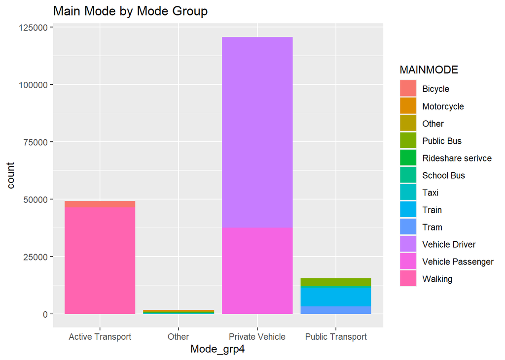

```r
ggplot(stops,aes(x = Mode_grp4, fill = MAINMODE))+geom_bar()+labs(title="Main Mode by Mode Group")
```

Here we can see trip stages are dominated by Private Vehicles (~120K), of which Vehicle Driver forms the majority.

The next highest mode group is active transport (~50K), mostly walking.

Public transport accounts for about 15 thousand trips, most of which are by train.

## 6.2 TRAVTIME

```r
summary(stops$TRAVTIME)
```

```
##    Min. 1st Qu.  Median    Mean 3rd Qu.    Max.
##    0.00    7.00   15.00   18.75   25.00 1081.00
```

The minimum value for TRAVTIME is 0 - this seems a little unintuitive but may not strictly be invalid if it is a rounding of a stage time that is almost instantaneous - eg. walking from a bus stop to a destination one door down. The maximum value of 1081 is unusual but not impossible. There may be a very long journey involved. It would be interesting to see where the trip stage goes and other characteristics of it. Seeking to quantify how many zero minute or extremely long travel there is:

```r
count.zero <- sum(stops$TRAVTIME == 0, na.rm = TRUE)
cat("Zero minute travel:",count.zero)
```

```
## Zero minute travel: 4
```

```r
count.over4 <- sum(stops$TRAVTIME > 240, na.rm = TRUE)
cat("\nTravel over four hours:",count.over4, "or ", count.over4/length(stops$TRAVTIME)*100,"%")
```

```
##
## Travel over four hours: 88 or  0.04711703 %
```

There are not even a handful of zero minute stages in the dataset. There are more stages over four hours, though still small relative to the entire size of the dataset.

Now we choose a subset which is small enough to examine closer:

```r
count.over12 <- sum(stops$TRAVTIME > 720, na.rm = TRUE)
cat("\nTravel over 12 hours:",count.over12)
```

```
##
## Travel over 12 hours: 9
```

```r
stops[stops$TRAVTIME > 720,]%>% select("ï..STOPID":"DESTPURP2")
```

```
##                ï..STOPID         PERSID        HHID STOPNO STARTHOUR STARTIME
## 61447  Y14H0890542P01S02 Y14H0890542P01 Y14H0890542      2        11      675
## 62976  Y14H0920507P03S01 Y14H0920507P03 Y14H0920507      1         6      405
## 70244  Y14H1020129P02S01 Y14H1020129P02 Y14H1020129      1         4      240
## 96006  Y15H1370213P01S02 Y15H1370213P01 Y15H1370213      2         7      470
## 172963 Y17H2540223P01S01 Y17H2540223P01 Y17H2540223      1         4      240
## 172965 Y17H2540223P02S01 Y17H2540223P02 Y17H2540223      1         4      240
## 177497 Y17H2810428P02S02 Y17H2810428P02 Y17H2810428      2         8      485
## 190417 Y18H2992321P02S01 Y18H2992321P02 Y18H2992321      1         4      240
## 197297 Y18H3040236P04S01 Y18H3040236P04 Y18H3040236      1         4      240
##        ARRHOUR ARRTIME DURATION DEPHOUR DEPTIME TRAVTIME VISTADIST
## 61447       23    1400      999      NA      NA      725       2.0
## 62976       19    1145      999      20    1230      740      12.5
## 70244       16     965      115      18    1080      725       3.2
## 96006       20    1200       45      20    1245      730       2.4
```

[output cut: 45 more lines]

4 of these trips are very long distance (over 2000), whereas the other 5 are 30 or less.

The stages over 2000 in distance are likely to be flights

The stages under 30km are all car or 4wd passenger trips. It is not clear why these would take more than 12 hours for such a short distance. Perhaps there was confusion around AM vs PM times.

This hypothesis is supported by the travel times for these stages being between 725 and 745. If you subtract 720 for 12 hours, the durations become reasonable for the distance covered.

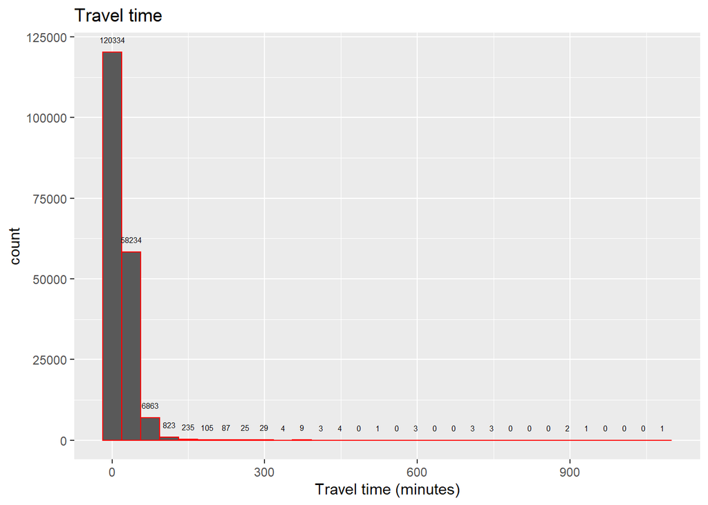

```r
plot_hist(stops$TRAVTIME,30)+xlim(0,720)+scale_x_continuous(name="Travel time (minutes)")+labs(title="Travel time")
```

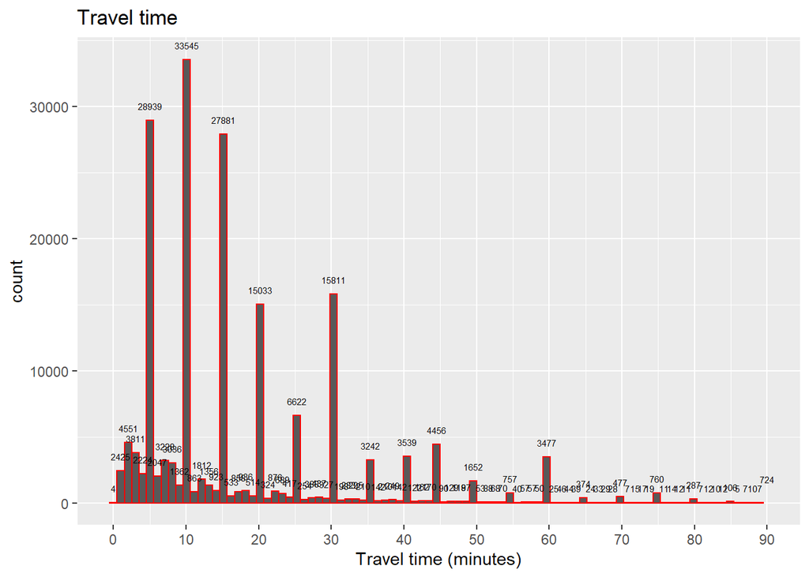

```r
plot_hist(stops$TRAVTIME,90)+scale_x_continuous(limits = c(NA,90),breaks = seq(0,90,10),name="Travel time (minutes)")+labs(title="Travel time")
```

The travel times are still right-skewed on the whole, but with very clear spikes around 5-minute increments, especially 5, 10, 15 and 30 minutes. This is not surprising as people would be most likely to remember and report travel times in these increments.

Is there covariation between travel time and mode group? A hypothesis is that public transport trips tend to take longer, active transport trips (walk and cycle) tend to be shorter, and private transport trips are in the middle.

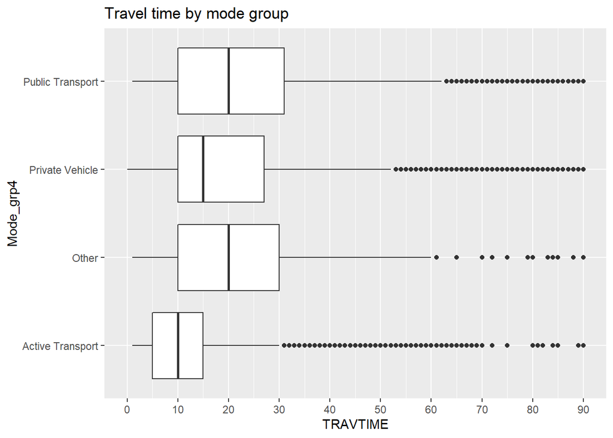

```r
ggplot(stops, aes(x=TRAVTIME, y = Mode_grp4))+geom_boxplot()+scale_x_continuous(limits = c(NA,90),breaks = seq(0,90,10))+labs(title="Travel time by mode group")
```

This is borne out through the above boxplot. Active transport trips are the shortest, with a median of 10 minutes, public transport trips have a median of 20, and private transport in the middle with 15. Interestingly, public and private transport have the same lower quartile of 10 minutes, however public transport has a higher upper quartile of 31 minutes vs 27 minutes.

One possible reason for this is that public transport includes short travel legs part of a longer journey (eg. a bus from your house to the local train station) as well as long trip legs (eg. a journey from the suburbs to the city), while more car trips are completed in one leg which may not take so long.

Another possible reason could be due to a split in large Australian cities such as Melbourne between inner city areas where there are many short trips made via public transport (lower quartile TRAVTIME) and more outer suburban areas where travel times over public transport can be very long due to the distances involved. This difference between inner city and suburban travel times is not as appreciable with private transport despite distances involved due to inner city streets being slower and more congested and parking being harder to find.

We can test the strength of each hypothesis by comparing trips within and between inner city and non-inner city areas. Whether or not an area is ‘inner-city’ is hard to determine and subjective, and the only location data this dataset has is LGA. A serviceable definition comes from the Victorian Regional Information Portal which defines the Inner Melbourne Functional Economic Area (IMFEA) as ‘Melbourne (C), Port Phillip (C), Stonnington (C), Yarra (C)’ (https://www.rdv.vic.gov.au/information-portal/more-information/region-descriptions-and-geography-structure). Based on this definition, we will create a column called ‘INNERCITYTRAVEL’ with values INNER (ORIGLGA and DESTLGA within IMFEA), NOT INNER (neither ORIGLGA nor DESTLGA within IMFEA), and INNER-OUTER (one but not both of ORIGLGA and DESTLGA within IMFEA)

```r
IMFEA <- c("Melbourne (C)", "Port Phillip (C)", "Stonnington (C)", "Yarra (C)")
stops$INNERCITYTRAVEL <- ifelse(stops$ORIGLGA %in% IMFEA & stops$DESTLGA %in% IMFEA,"INNER",ifelse(!(stops$ORIGLGA %in% IMFEA) & !(stops$DESTLGA %in% IMFEA),"NOT INNER","INNER-OUTER"))
head(stops %>% select("ORIGLGA","DESTLGA","INNERCITYTRAVEL"))
```

```
##          ORIGLGA        DESTLGA INNERCITYTRAVEL
## 1 Whittlesea (C) Whittlesea (C)       NOT INNER
## 3 Whittlesea (C) Whittlesea (C)       NOT INNER
## 4 Whittlesea (C) Whittlesea (C)       NOT INNER
## 5 Whittlesea (C) Whittlesea (C)       NOT INNER
## 6 Whittlesea (C) Whittlesea (C)       NOT INNER
## 8 Whittlesea (C) Whittlesea (C)       NOT INNER
```

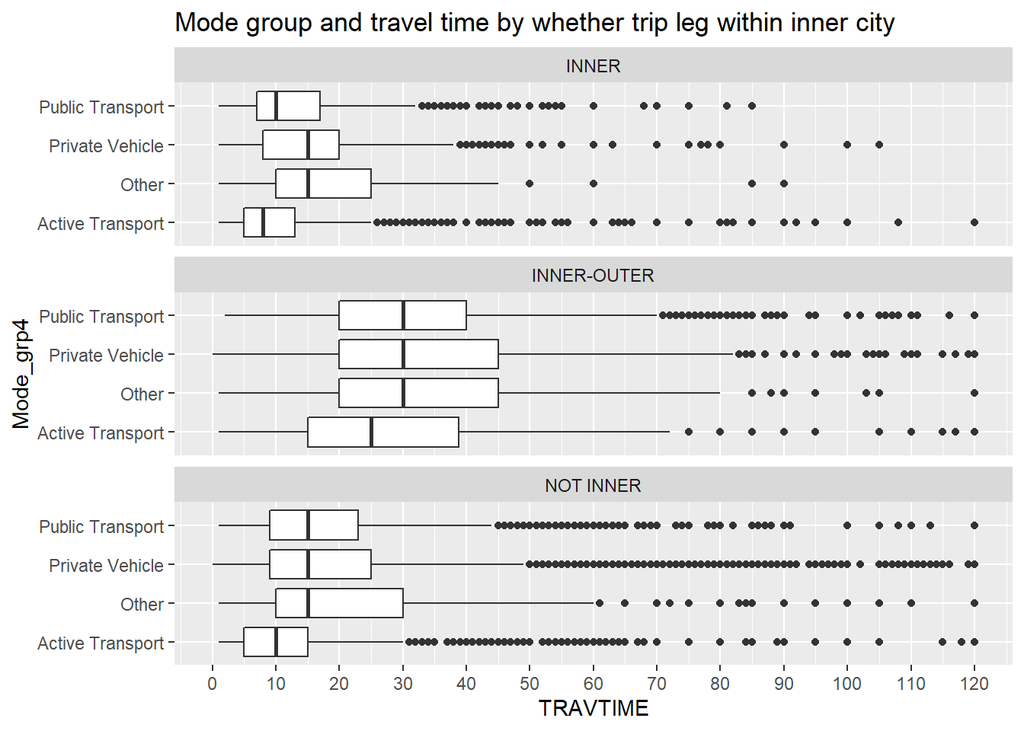

```r
ggplot(stops, aes(x=TRAVTIME, y = Mode_grp4))+geom_boxplot()+scale_x_continuous(limits = c(NA,120),breaks = seq(0,120,10))+facet_wrap(~ INNERCITYTRAVEL,nrow=3)+labs(title="Mode group and travel time by whether trip leg within inner city")
```

For travel within the inner city, public transport is actually markedly faster than private vehicles, with a median of 10 minutes vs 15, and active transport has a median of only 8 minutes. This is consistent with the theory of public transport being quick and car travel being slow in the inner city due to slow streets and parking.

For travel entirely outside the inner city, public and private transport have equal median TRAVTIME of 15 minutes, although public transport has a shorter upper quartile of 23 minutes vs 25. This is consistent with many public transport trip legs outside the inner city containing many quick trips within local areas to transport hubs.

For travel to or from the inner city, public and private transport have the same higher median of 30 minutes, although private vehicles have a higher upper quartile at 45 vs 40 for public transport.

This result, however presents a bit of a puzzle. In aggregate, public transport has a higher upper quartile TRAVTIME than private vehicle, but when divided out by whether either or both of the LGAs are inner city, public transport in each instance has an upper quartile TRAVTIME which is lower than private vehicle (and a median and lower quartile while is equal or lower).

Let’s look at the relative numbers in each INNERCITYTRAVEL category:

```r
table(stops$INNERCITYTRAVEL)
```

```
##
##       INNER INNER-OUTER   NOT INNER
##       25656       19597      141516
```

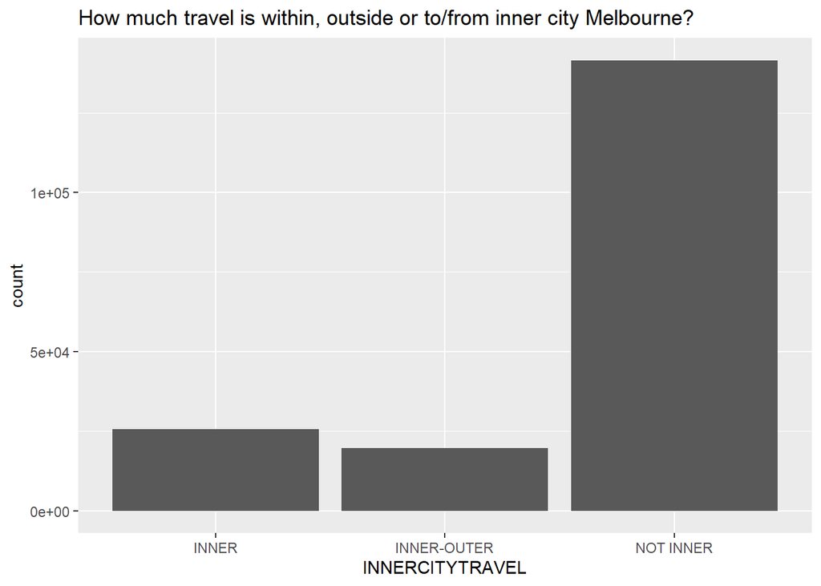

```r
ggplot(stops,aes(x = INNERCITYTRAVEL))+geom_bar()+labs(title="How much travel is within, outside or to/from inner city Melbourne?")
```

The ‘NOT INNER’ category is several times larger than the other categories combined.

```r
Inner_Mode <- table(stops$INNERCITYTRAVEL,stops$Mode_grp4)
Inner_Mode
```

```
##
##               Active Transport  Other Private Vehicle Public Transport
##   INNER                  17275    246            4580             3555
##   INNER-OUTER             1019    278           11490             6810
##   NOT INNER              30823   1038          104532             5123
```

```r
#get percentage of each mode per INNERCTIYTRAVEL
cbind(as.data.frame.matrix(Inner_Mode)/rowSums(as.data.frame.matrix(Inner_Mode))*100,"100%")
```

```
##             Active Transport    Other Private Vehicle Public Transport "100%"
## INNER              67.333177 0.958840        17.85157        13.856408   100%
## INNER-OUTER         5.199775 1.418584        58.63142        34.750217   100%
## NOT INNER          21.780576 0.733486        73.86585         3.620085   100%
```

```r
#get percentage of each INNERCTIYTRAVEL per mode
Mode_Inner <- table(stops$Mode_grp4,stops$INNERCITYTRAVEL)
cbind(as.data.frame.matrix(Mode_Inner)/rowSums(as.data.frame.matrix(Mode_Inner))*100,"100%")
```

```
##                      INNER INNER-OUTER NOT INNER "100%"
## Active Transport 35.171122    2.074638  62.75424   100%
## Other            15.749040   17.797695  66.45327   100%
## Private Vehicle   3.797615    9.527205  86.67518   100%
## Public Transport 22.953254   43.969525  33.07722   100%
```

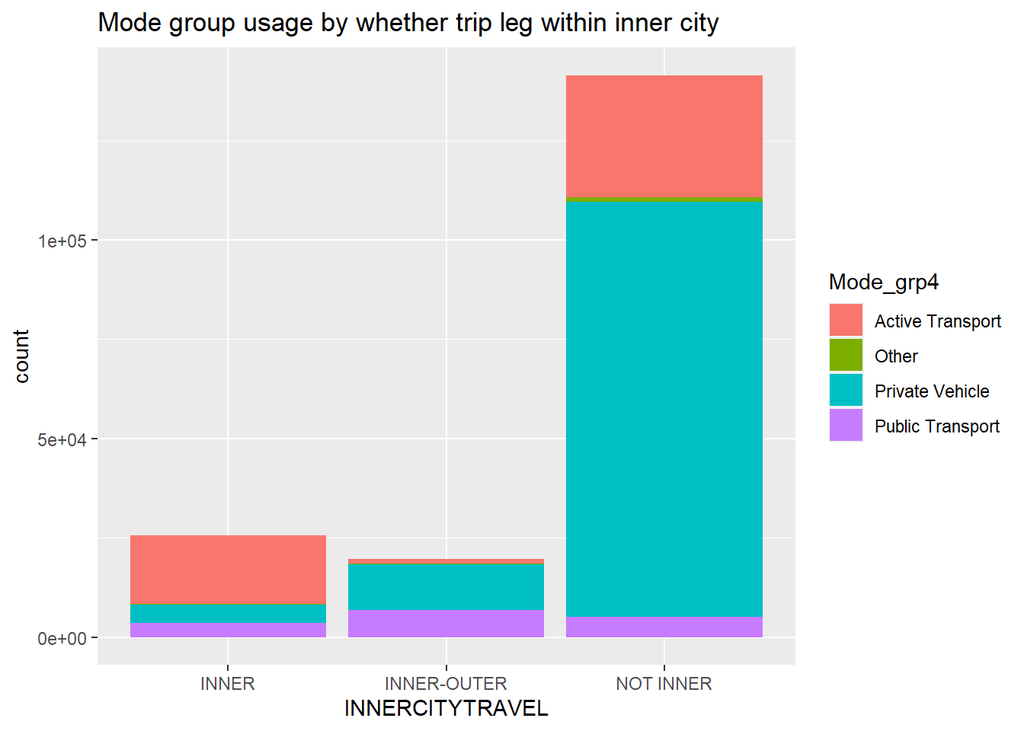

```r
ggplot(stops,aes(x = INNERCITYTRAVEL, fill = Mode_grp4))+geom_bar()+labs(title="Mode group usage by whether trip leg within inner city")
```

Public transport forms several times higher a proportion travel to and from the inner city (35%) and within it (14%) than outside (less than 4%), despite being similar in magnitude in absolute numbers (4 to 7 thousand).

Conversely and more importantly, private vehicle use is overwhelmingly in travel outside the inner city (87%), while only a small proportion of private vehicle use is for trips between inner and outer areas (under 10%) or within inner areas (4%). It is the wide variation in proportion of private vehicle use within each category that allows upper quartile TRAVTIME to be higher than public transport for each category but lower in aggregate. A trend being reversed in groups vs in aggregate is a well-known statistical phenomenon, Simpsons’s Paradox (https://en.wikipedia.org/wiki/Simpson%27s_paradox).

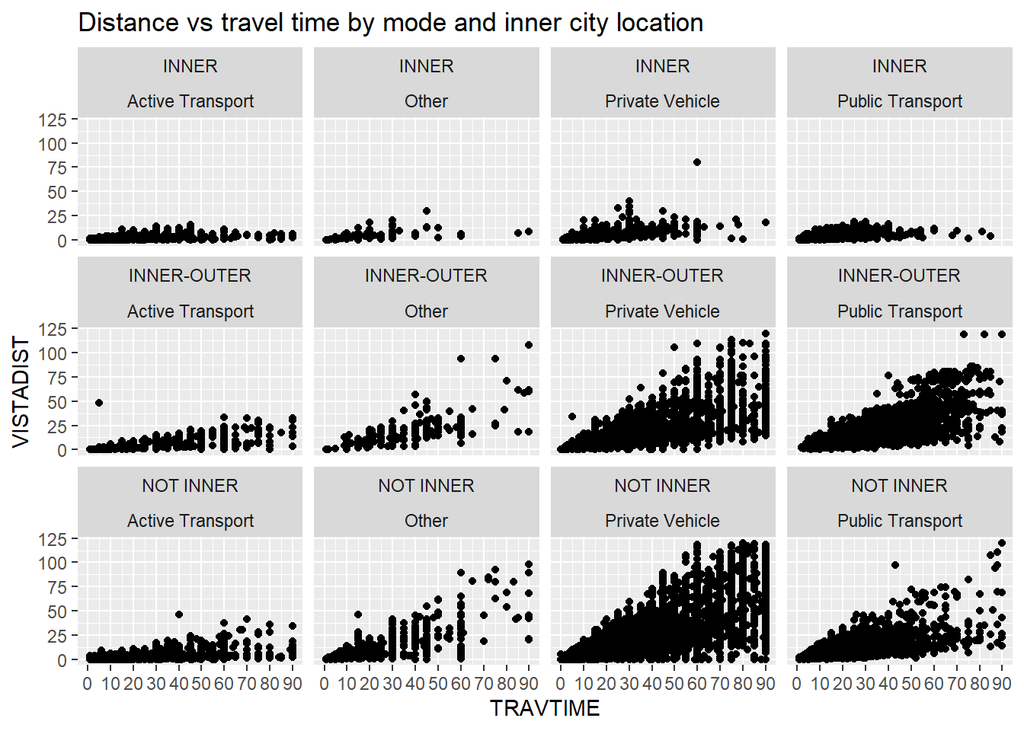

```r
ggplot(data = stops)+geom_point(mapping = aes(x=TRAVTIME,y=VISTADIST),show.legend = TRUE)+labs(title = "Distance vs travel time by mode and inner city location")+scale_x_continuous(limits = c(NA,90),breaks = seq(0,90,10))+scale_y_continuous(limits = c(NA,120))+facet_wrap(INNERCITYTRAVEL~Mode_grp4,nrow=3)
```

For public transport clusters of short travtime trips across all categories, and long travtime trips to and from the inner city, are both evident.

Also of note in relation to our earlier remarks about rounding trip times to multiples of five, this rounding is less obvious for public transport, perhaps because participants can refer to exact timetable and smart card data rather than just estimating how long their trips took.

Does travel time vary depending on whether it was a weekday or a weekend?

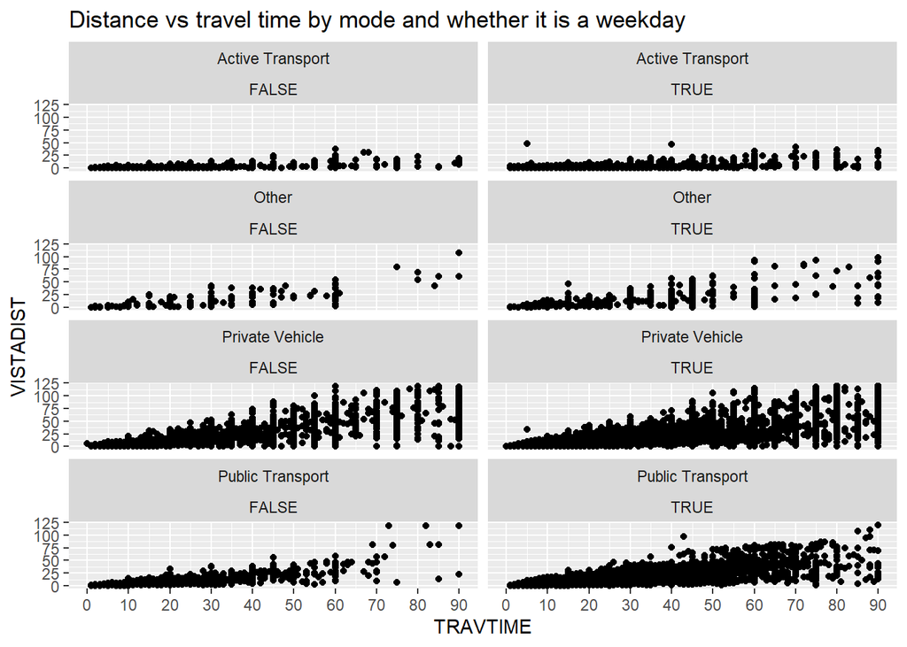

```r
ggplot(data = stops)+geom_point(mapping = aes(x=TRAVTIME,y=VISTADIST),show.legend = TRUE)+labs(title = "Distance vs travel time by mode and whether it is a weekday")+scale_x_continuous(limits = c(NA,90),breaks = seq(0,90,10))+scale_y_continuous(limits = c(NA,120))+facet_wrap(Mode_grp4~ISWEEKDAY,nrow=4)
```

On weekdays longer duration trips tend to be taken. This could be due to increased congestion on weekdays, or commuters travelling further to work compared to other purposes, or commuters being focused on proceeding straight to work rather than being willing to take leisurely detours and break trips on weekends.

## 6.3 Trip places

```r
table(stops$ORIGPLACE1)
```

```
##
##              Accommodation            Natural Feature
##                      77744                       2798
##                      Other         Place of Education
##                       2416                      14074
## Place of Personal Business         Recreational Place
##                       5588                       7865
##                      Shops               Social Place
##                      18935                       8605
##          Transport Feature                  Workplace
##                      29361                      19383
```

```r
table(stops$ORIGPLACE2)
```

```
##
##                      2nd Home             Accommodation NEC
##                           188                           126
##                       Airport     Amusement or Bingo Centre
##                           262                            11
##             Another Workplace         Antiques & Secondhand
##                          3648                            68
## Bank or Financial Institution                  Bay or Beach
##                           334                            35
##                     Bike Rack                      Bus Stop
##                             3                          6399
##                      Campsite               Car Accessories
##                             6                           123
##                      Car Park                   Car Service
##                           706                           292
##                  Caravan Park                       Chemist
##                            38                           336
##                     Childcare                        Cinema
##                          1060                           159
##               Clothes & Shoes                          Club
##                           200                           266
##              Community Centre             Computer or Music
##                           241                           121
##             Conference Centre             Convenience Store
##                            12                           115
##                Craft or Hobby                 Death Service
##                            66                            95
##  Department or Discount Store           Domestic Appliances
##                           364                            57
##                 Education NEC             Emergency Service
##                           362                            40
##                          Farm                     Fast Food
##                             8                           902
##                       Florist                    Food Store
##                            27                           779
##                        Forest                     Furniture
##                           100                            87
##             Gallery or Museum                      Gambling
##                           149                            40
##                 Garden Centre          Geographical Feature
```

[output cut: 66 more lines]

```
##                             6                          1040
##                       Theatre                   Tobacconist
##                           120                             2
##                 Tourist Place                      Toy Shop
##                           203                            11
##                 Train Station                     Tram Stop
##                         15575                          6110
##                 Transport NEC                 Vehicle Sales
##                            46                            54
##                Vets & Kennels                         Video
##                           106                            22
##        Waste Disposal Service           Waterside Structure
##                           103                            42
##                 Workplace NEC
##                          3161
```

```r
cat(nlevels(factor(stops$ORIGPLACE2))," Levels")
```

```
## 119  Levels
```

ORIGPLACE1 consists of broad categories while ORIGPLACE2 consists of finer detailed categories

```r
gsub(" 0", " ", kable(table(select(stops,c(ORIGPLACE2,ORIGPLACE1)))))
```

|  | Accommodation | Natural Feature | Other | Place of Education | Place of Personal Business | Recreational Place | Shops | Social Place | Transport Feature | Workplace |
| --- | --- | --- | --- | --- | --- | --- | --- | --- | --- | --- |
| 2nd Home | 188 |  |  |  |  |  |  |  |  |  |
| Accommodation NEC | 126 |  |  |  |  |  |  |  |  |  |
| Airport |  |  |  |  |  |  |  |  | 262 |  |
| Amusement or Bingo Centre |  |  |  |  |  |  |  | 11 |  |  |
| Another Workplace |  |  |  |  |  |  |  |  |  | 3648 |
| Antiques & Secondhand |  |  |  |  |  |  | 68 |  |  |  |
| Bank or Financial Institution |  |  |  |  | 334 |  |  |  |  |  |
| Bay or Beach |  | 35 |  |  |  |  |  |  |  |  |
| Bike Rack |  |  |  |  |  |  |  |  | 3 |  |
| Bus Stop |  |  |  |  |  |  |  |  | 6399 |  |
| Campsite | 6 |  |  |  |  |  |  |  |  |  |
| Car Accessories |  |  |  |  |  |  | 123 |  |  |  |
| Car Park |  |  |  |  |  |  |  |  | 706 |  |
| Car Service |  |  |  |  | 292 |  |  |  |  |  |
| Caravan Park | 38 |  |  |  |  |  |  |  |  |  |
| Chemist |  |  |  |  |  |  | 336 |  |  |  |
| Childcare |  |  |  | 1060 |  |  |  |  |  |  |
| Cinema |  |  |  |  |  |  |  | 159 |  |  |
| Clothes & Shoes |  |  |  |  |  |  | 200 |  |  |  |
| Club |  |  |  |  |  |  |  | 266 |  |  |
| Community Centre |  |  |  |  |  |  |  | 241 |  |  |
| Computer or Music |  |  |  |  |  |  | 121 |  |  |  |
| Conference Centre |  |  |  |  |  |  |  |  |  | 12 |
| Convenience Store |  |  |  |  |  |  | 115 |  |  |  |
| Craft or Hobby |  |  |  |  |  |  | 66 |  |  |  |
| Death Service |  |  |  |  | 95 |  |  |  |  |  |
| Department or Discount Store |  |  |  |  |  |  | 364 |  |  |  |
| Domestic Appliances |  |  |  |  |  |  | 57 |  |  |  |
| Education NEC |  |  |  | 362 |  |  |  |  |  |  |
| Emergency Service |  |  |  |  | 40 |  |  |  |  |  |

[output cut: 89 more lines]

Each ORIGPLACE2 category comes entirely under one ORIGPLACE1 category, except for Other NEC which has 1 instance under Recreation Place instead of other (may be a data entry error).

Are the Destination Place categories similar to Origin Place?

```r
table(stops$DESTPLACE1)
```

```
##
##              Accommodation            Natural Feature
##                      64151                       3456
##                      Other         Place of Education
##                       1391                      16394
## Place of Personal Business         Recreational Place
##                       6320                       9534
##                      Shops               Social Place
##                      22157                       9926
##          Transport Feature                  Workplace
##                      31148                      22292
```

```r
cbind(levels(factor(stops$DESTPLACE1)),levels(factor(stops$ORIGPLACE1)))
```

```
##       [,1]                         [,2]
##  [1,] "Accommodation"              "Accommodation"
##  [2,] "Natural Feature"            "Natural Feature"
##  [3,] "Other"                      "Other"
##  [4,] "Place of Education"         "Place of Education"
##  [5,] "Place of Personal Business" "Place of Personal Business"
##  [6,] "Recreational Place"         "Recreational Place"
##  [7,] "Shops"                      "Shops"
##  [8,] "Social Place"               "Social Place"
##  [9,] "Transport Feature"          "Transport Feature"
## [10,] "Workplace"                  "Workplace"
```

```r
cat(nlevels(factor(stops$DESTPLACE2))," Levels")
```

```
## 120  Levels
```

```r
cbind(levels(factor(stops$DESTPLACE2)),levels(factor(stops$ORIGPLACE2)),levels(factor(stops$DESTPLACE2))==levels(factor(stops$ORIGPLACE2)))
```

```
##        [,1]                            [,2]                            [,3]
##   [1,] "2nd Home"                      "2nd Home"                      "TRUE"
##   [2,] "409"                           "Accommodation NEC"             "FALSE"
##   [3,] "Accommodation NEC"             "Airport"                       "FALSE"
##   [4,] "Airport"                       "Amusement or Bingo Centre"     "FALSE"
##   [5,] "Amusement or Bingo Centre"     "Another Workplace"             "FALSE"
##   [6,] "Another Workplace"             "Antiques & Secondhand"         "FALSE"
##   [7,] "Antiques & Secondhand"         "Bank or Financial Institution" "FALSE"
##   [8,] "Bank or Financial Institution" "Bay or Beach"                  "FALSE"
##   [9,] "Bay or Beach"                  "Bike Rack"                     "FALSE"
##  [10,] "Bike Rack"                     "Bus Stop"                      "FALSE"
##  [11,] "Bus Stop"                      "Campsite"                      "FALSE"
##  [12,] "Campsite"                      "Car Accessories"               "FALSE"
##  [13,] "Car Accessories"               "Car Park"                      "FALSE"
##  [14,] "Car Park"                      "Car Service"                   "FALSE"
```

[output cut: 106 more lines]

DESTPLACE2 contains 409 whereas ORIGPLACE2 does not. As we can see below, every other value is the same.

```r
cbind(levels(factor(stops$DESTPLACE2))%>%rev(),levels(factor(stops$ORIGPLACE2))%>%rev(),levels(factor(stops$DESTPLACE2))%>%rev()==levels(factor(stops$ORIGPLACE2))%>%rev())
```

```
##        [,1]                            [,2]                            [,3]
##   [1,] "Workplace NEC"                 "Workplace NEC"                 "TRUE"
##   [2,] "Waterside Structure"           "Waterside Structure"           "TRUE"
##   [3,] "Waste Disposal Service"        "Waste Disposal Service"        "TRUE"
##   [4,] "Video"                         "Video"                         "TRUE"
##   [5,] "Vets & Kennels"                "Vets & Kennels"                "TRUE"
##   [6,] "Vehicle Sales"                 "Vehicle Sales"                 "TRUE"
##   [7,] "Transport NEC"                 "Transport NEC"                 "TRUE"
##   [8,] "Tram Stop"                     "Tram Stop"                     "TRUE"
##   [9,] "Train Station"                 "Train Station"                 "TRUE"
##  [10,] "Toy Shop"                      "Toy Shop"                      "TRUE"
##  [11,] "Tourist Place"                 "Tourist Place"                 "TRUE"
##  [12,] "Tobacconist"                   "Tobacconist"                   "TRUE"
##  [13,] "Theatre"                       "Theatre"                       "TRUE"
##  [14,] "Tertiary"                      "Tertiary"                      "TRUE"
```

[output cut: 106 more lines]

Recall during the data cleaning records with 409 in ORIGPLACE2 were dropped but not DESTPLACE2. It would’ve been cleaner to drop the columns in DESTPLACE2 as well, but the argument could also be made that the 409 values could signify something.

```r
gsub(" 0", " ", kable(table(select(stops,c(DESTPLACE2,DESTPLACE1)))))
```

|  | Accommodation | Natural Feature | Other | Place of Education | Place of Personal Business | Recreational Place | Shops | Social Place | Transport Feature | Workplace |
| --- | --- | --- | --- | --- | --- | --- | --- | --- | --- | --- |
| 2nd Home | 294 |  |  |  |  |  |  |  |  |  |
| 409 |  | 8 |  |  |  |  |  |  |  |  |
| Accommodation NEC | 201 |  |  |  |  |  |  |  |  |  |
| Airport |  |  |  |  |  |  |  |  | 323 |  |
| Amusement or Bingo Centre |  |  |  |  |  |  |  | 12 |  |  |
| Another Workplace |  |  |  |  |  |  |  |  |  | 3999 |
| Antiques & Secondhand |  |  |  |  |  |  | 72 |  |  |  |
| Bank or Financial Institution |  |  |  |  | 352 |  |  |  |  |  |
| Bay or Beach |  | 36 |  |  |  |  |  |  |  |  |
| Bike Rack |  |  |  |  |  |  |  |  | 4 |  |
| Bus Stop |  |  |  |  |  |  |  |  | 6887 |  |
| Campsite | 25 |  |  |  |  |  |  |  |  |  |
| Car Accessories |  |  |  |  |  |  | 141 |  |  |  |
| Car Park |  |  |  |  |  |  |  |  | 753 |  |
| Car Service |  |  |  |  | 332 |  |  |  |  |  |
| Caravan Park | 82 |  |  |  |  |  |  |  |  |  |
| Chemist |  |  |  |  |  |  | 397 |  |  |  |
| Childcare |  |  |  | 1312 |  |  |  |  |  |  |
| Cinema |  |  |  |  |  |  |  | 194 |  |  |
| Clothes & Shoes |  |  |  |  |  |  | 213 |  |  |  |
| Club |  |  |  |  |  |  |  | 337 |  |  |
| Community Centre |  |  |  |  |  |  |  | 287 |  |  |
| Computer or Music |  |  |  |  |  |  | 130 |  |  |  |
| Conference Centre |  |  |  |  |  |  |  |  |  | 12 |
| Convenience Store |  |  |  |  |  |  | 127 |  |  |  |
| Craft or Hobby |  |  |  |  |  |  | 67 |  |  |  |
| Death Service |  |  |  |  | 105 |  |  |  |  |  |
| Department or Discount Store |  |  |  |  |  |  | 397 |  |  |  |
| Domestic Appliances |  |  |  |  |  |  | 62 |  |  |  |
| Education NEC |  |  |  | 424 |  |  |  |  |  |  |

[output cut: 90 more lines]

```r
for (destplace1 in levels(factor(stops$DESTPLACE1))) {
  print(toupper(destplace1))
  print("Origin")
  table(stops[stops$ORIGPLACE1==destplace1,]$ORIGPLACE2) %>% print()
  print("Destination")
  table(stops[stops$DESTPLACE1==destplace1,]$DESTPLACE2) %>% print()
}
```

```
## [1] "ACCOMMODATION"
## [1] "Origin"
##
##            2nd Home   Accommodation NEC            Campsite        Caravan Park
##                 188                 126                   6                  38
##                Farm      Hotel or Motel        Nursing Home  Retirement Village
##                   8                 250                 205                  51
## Someone Else's Home         Survey Home
##                8760               68112
## [1] "Destination"
##
##            2nd Home   Accommodation NEC            Campsite        Caravan Park
##                 294                 201                  25                  82
##                Farm      Hotel or Motel        Nursing Home  Retirement Village
##                   8                 368                 235                  57
## Someone Else's Home         Survey Home
##               11096               51785
## [1] "NATURAL FEATURE"
## [1] "Origin"
##
##          Bay or Beach                Forest  Geographical Feature
##                    35                   100                     7
##     Lake or Reservoir               Lookout                  Park
##                   468                    16                  2120
## Physical Features NEC
##                    52
## [1] "Destination"
##
##                   409          Bay or Beach                Forest
##                     8                    36                   117
##  Geographical Feature     Lake or Reservoir               Lookout
##                     9                   604                    16
##                  Park Physical Features NEC
##                  2603                    63
## [1] "OTHER"
## [1] "Origin"
##
## Other NEC
##      2416
## [1] "Destination"
```

[output cut: 191 more lines]

```
##             Airport           Bike Rack            Bus Stop            Car Park
##                 323                   4                6887                 753
##   On-Street Feature          Taxi Stand       Train Station           Tram Stop
##                 250                   2               16508                6321
##       Transport NEC Waterside Structure
##                  47                  53
## [1] "WORKPLACE"
## [1] "Origin"
##
## Another Workplace Conference Centre      My Workplace     Workplace NEC
##              3648                12             12562              3161
## [1] "Destination"
##
## Another Workplace Conference Centre      My Workplace     Workplace NEC
##              3999                12             14709              3572
```

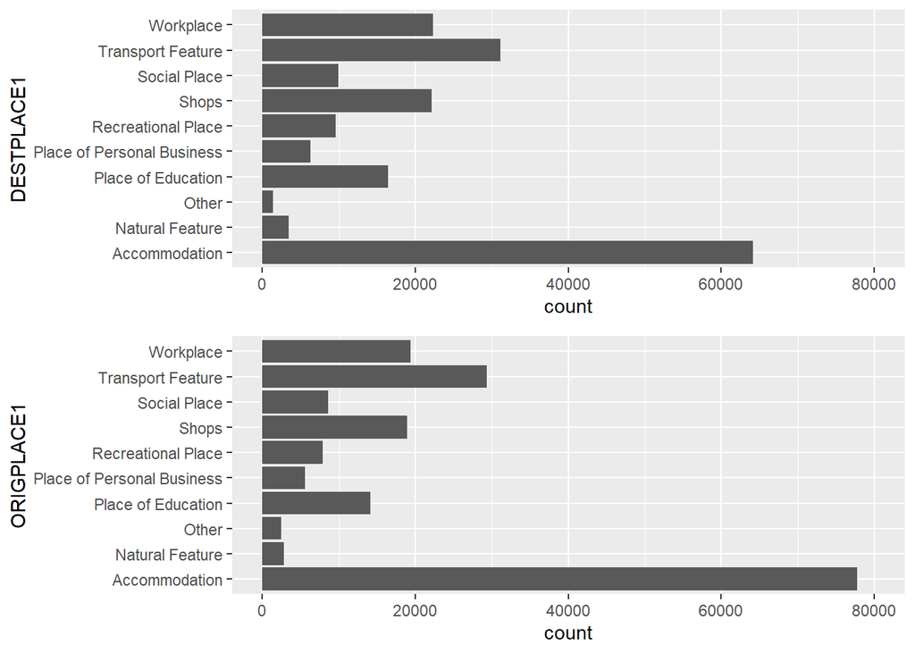

```r
p1 <- ggplot(stops,aes(y = DESTPLACE1))+geom_bar()+xlim(0,80000)
p2 <- ggplot(stops,aes(y = ORIGPLACE1))+geom_bar()+xlim(0,80000)
grid.arrange(p1, p2)
```

Accommodation is the most common origin place and destination place by far, which makes sense, followed by Transport Feature, Workplace, Shops and Place of Education.

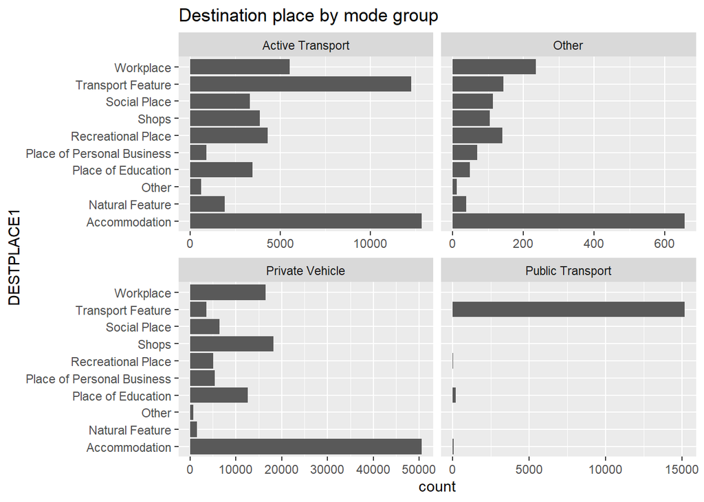

```r
ggplot(stops,aes(y = DESTPLACE1))+geom_bar()+facet_wrap(~Mode_grp4,scale="free_x")+labs(title="Destination place by mode group")
```

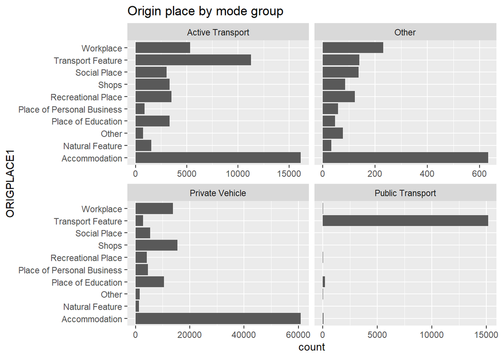

```r
ggplot(stops,aes(y = ORIGPLACE1))+geom_bar()+facet_wrap(~Mode_grp4,scale="free_x")+labs(title="Origin place by mode group")
```

Public transport is used predominantly for trips to Transport Features, which is expected as this is how public transport is accessed (train stations, bus stops etc.). The few cases of a different origplace or destplace would have to be cases where public transport stops right at the door of say a workplace, without a walking trip being involved.

Active transport is predominantly used to access accomodation and transport features, which is consistent with travellers walking between their home and their local public transport stop. There is also moderate use of active transport to access other places.

Private vehicles are used mostly to access accomodation, workplaces, shops and places of education, and moderately to access other places.

## 6.4 Trip purposes

```r
table(stops$ORIGPURP1)
```

```
##
##                 Accompany Someone                           At Home
##                              5154                             68089
##                     Buy Something                       Change Mode
##                             15836                             28372
##                         Education                           Missing
##                              5674                                 3
##                     Other Purpose                 Personal Business
##                               482                              7228
##      Pick-up or Deliver Something       Pick-up or Drop-off Someone
##                              2127                             10920
##                      Recreational                            Social
##                              7255                             14779
## Unknown Purpose (at start of day)                      Work Related
##                              1631                             19219
```

```r
table(stops$ORIGPURP2)
```

```
##
##                       Accompanied someone
##                                      5147
##                              At childcare
##                                         7
##                             At or Go Home
##                                     68089
##                            At other house
##                                        55
##             At other Post-Secondary Study
##                                         1
##                                 At school
##                                      4723
##                               At Uni/Tech
##                                       762
##                              Ate or drank
##                                      6715
##                          Bought something
##                                     15750
##                 Browsing, window-shopping
##                                        86
##                         Change Mode (NEC)
##                                       104
##                           Education (NEC)
##                                       121
##                        Employers Business
##                                      4201
##                          Got on or off PT
##                                     26934
##                   Medical/Dental purposes
##                                      1716
##                    Met/waited for someone
##                                       128
##                                Not stated
##                                         3
##                               Other (NEC)
##                                       482
##         Other recreational (eg. exercise)
##                                      5598
##                             Own Workplace
```

[output cut: 26 more lines]

```
##                                       218
##                 Unknown (at start of day)
##                                      1631
##                           Visited someone
##                                      5889
##              Volunteer/Community activity
##                                       260
##                            Walked the dog
##                                      2144
##               Watched concert, movies etc
##                                       494
##                             Watched sport
##                                       456
##                        Work-Related (NEC)
##                                         6
```

```r
cat(nlevels(factor(stops$ORIGPURP2))," Levels")
```

```
## 40  Levels
```

```r
table(stops$ORIGPURP1)
```

```
##
##                 Accompany Someone                           At Home
##                              5154                             68089
##                     Buy Something                       Change Mode
##                             15836                             28372
##                         Education                           Missing
##                              5674                                 3
##                     Other Purpose                 Personal Business
##                               482                              7228
##      Pick-up or Deliver Something       Pick-up or Drop-off Someone
##                              2127                             10920
##                      Recreational                            Social
##                              7255                             14779
## Unknown Purpose (at start of day)                      Work Related
##                              1631                             19219
```

```r
table(stops$ORIGPURP2)
```

```
##
##                       Accompanied someone
##                                      5147
##                              At childcare
##                                         7
##                             At or Go Home
##                                     68089
##                            At other house
##                                        55
##             At other Post-Secondary Study
##                                         1
##                                 At school
##                                      4723
##                               At Uni/Tech
##                                       762
##                              Ate or drank
##                                      6715
##                          Bought something
##                                     15750
##                 Browsing, window-shopping
##                                        86
##                         Change Mode (NEC)
##                                       104
##                           Education (NEC)
##                                       121
##                        Employers Business
##                                      4201
##                          Got on or off PT
##                                     26934
##                   Medical/Dental purposes
##                                      1716
##                    Met/waited for someone
##                                       128
##                                Not stated
##                                         3
##                               Other (NEC)
##                                       482
##         Other recreational (eg. exercise)
##                                      5598
##                             Own Workplace
```

[output cut: 26 more lines]

```
##                                       218
##                 Unknown (at start of day)
##                                      1631
##                           Visited someone
##                                      5889
##              Volunteer/Community activity
##                                       260
##                            Walked the dog
##                                      2144
##               Watched concert, movies etc
##                                       494
##                             Watched sport
##                                       456
##                        Work-Related (NEC)
##                                         6
```

```r
cat(nlevels(factor(stops$ORIGPURP2))," Levels")
```

```
## 40  Levels
```

```r
cbind(levels(factor(stops$DESTPURP2)),levels(factor(stops$ORIGPURP2)),levels(factor(stops$DESTPURP2))==levels(factor(stops$ORIGPURP2)))
```

```
##       [,1]
##  [1,] "Accompanied someone"
##  [2,] "At childcare"
##  [3,] "At or Go Home"
##  [4,] "At other house"
##  [5,] "At other Post-Secondary Study"
##  [6,] "At school"
##  [7,] "At Uni/Tech"
##  [8,] "Ate or drank"
##  [9,] "Bought something"
## [10,] "Browsing, window-shopping"
## [11,] "Change Mode (NEC)"
## [12,] "Education (NEC)"
## [13,] "Employers Business"
## [14,] "Got on or off PT"
```

[output cut: 67 more lines]

```r
gsub(" 0", " ", kable(table(select(stops,c(ORIGPURP2,ORIGPURP1)))))
```

|  | Accompany Someone | At Home | Buy Something | Change Mode | Education | Missing | Other Purpose | Personal Business | Pick-up or Deliver Something | Pick-up or Drop-off Someone | Recreational | Social | Unknown Purpose (at start of day) | Work Related |
| --- | --- | --- | --- | --- | --- | --- | --- | --- | --- | --- | --- | --- | --- | --- |
| Accompanied someone | 5054 |  |  | 26 | 67 |  |  |  |  |  |  |  |  |  |
| At childcare |  |  |  |  |  |  |  | 7 |  |  |  |  |  |  |
| At or Go Home |  | 68089 |  |  |  |  |  |  |  |  |  |  |  |  |
| At other house | 1 |  |  |  |  |  |  | 54 |  |  |  |  |  |  |
| At other Post-Secondary Study |  |  |  |  | 1 |  |  |  |  |  |  |  |  |  |
| At school |  |  |  |  | 4723 |  |  |  |  |  |  |  |  |  |
| At Uni/Tech |  |  |  |  | 762 |  |  |  |  |  |  |  |  |  |
| Ate or drank |  |  |  |  |  |  |  |  |  |  |  | 6715 |  |  |
| Bought something |  |  | 15750 |  |  |  |  |  |  |  |  |  |  |  |
| Browsing, window-shopping |  |  | 86 |  |  |  |  |  |  |  |  |  |  |  |
| Change Mode (NEC) |  |  |  | 104 |  |  |  |  |  |  |  |  |  |  |
| Education (NEC) |  |  |  |  | 121 |  |  |  |  |  |  |  |  |  |
| Employers Business |  |  |  |  |  |  |  |  |  |  |  |  |  | 4201 |
| Got on or off PT |  |  |  | 26934 |  |  |  |  |  |  |  |  |  |  |
| Medical/Dental purposes | 96 |  |  |  |  |  |  | 1620 |  |  |  |  |  |  |
| Met/waited for someone | 3 |  |  |  |  |  |  | 125 |  |  |  |  |  |  |
| Not stated |  |  |  |  |  | 3 |  |  |  |  |  |  |  |  |
| Other (NEC) |  |  |  |  |  |  | 482 |  |  |  |  |  |  |  |
| Other recreational (eg. exercise) |  |  |  |  |  |  |  |  |  |  | 5598 |  |  |  |
| Own Workplace |  |  |  |  |  |  |  |  |  |  |  |  |  | 15008 |
| Parked or unparked a vehicle |  |  |  | 1308 |  |  |  |  |  |  |  |  |  |  |
| Participated in concert,musical,band etc |  |  |  |  |  |  |  |  |  |  | 60 |  |  |  |
| Participated in sport |  |  |  |  |  |  |  |  |  |  | 890 |  |  |  |
| Personal business (eg banking) |  |  |  |  |  |  |  | 1223 |  |  |  |  |  |  |
| Personal Business (NEC) |  |  |  |  |  |  |  | 786 |  |  |  |  |  |  |
| Recreational (NEC) |  |  |  |  |  |  |  |  |  |  | 705 |  |  |  |
| Religious activity |  |  |  |  |  |  |  | 793 |  |  |  |  |  |  |
| Social (NEC) |  |  |  |  |  |  |  |  |  |  |  | 1137 |  |  |
| Socialised (Pubs, Clubs etc) |  |  |  |  |  |  |  |  |  |  |  | 88 |  |  |
| Someone picked-up or delivered |  |  |  |  |  |  |  |  |  | 10920 |  |  |  |  |
| Something picked-up or delivered for home |  |  |  |  |  |  |  |  | 2127 |  |  |  |  |  |
| Something picked-up or delivered for Work |  |  |  |  |  |  |  |  |  |  |  |  |  | 4 |
| Stayed overnight |  |  |  |  |  |  |  | 216 |  |  | 2 |  |  |  |
| Unknown (at start of day) |  |  |  |  |  |  |  |  |  |  |  |  | 1631 |  |
| Visited someone |  |  |  |  |  |  |  |  |  |  |  | 5889 |  |  |
| Volunteer/Community activity |  |  |  |  |  |  |  | 260 |  |  |  |  |  |  |
| Walked the dog |  |  |  |  |  |  |  | 2144 |  |  |  |  |  |  |
| Watched concert, movies etc |  |  |  |  |  |  |  |  |  |  |  | 494 |  |  |
| Watched sport |  |  |  |  |  |  |  |  |  |  |  | 456 |  |  |
| Work-Related (NEC) |  |  |  |  |  |  |  |  |  |  |  |  |  | 6 |

```r
gsub(" 0", " ", kable(table(select(stops,c(DESTPURP2,DESTPURP1)))))
```

|  | Accompany Someone | Buy Something | Change Mode | Education | Go Home | Missing | Other Purpose | Personal Business | Pick-up or Deliver Something | Pick-up or Drop-off Someone | Recreational | Social | Work Related |
| --- | --- | --- | --- | --- | --- | --- | --- | --- | --- | --- | --- | --- | --- |
| Accompanied someone | 5910 |  | 28 | 75 |  |  |  |  |  |  |  |  |  |
| At childcare |  |  |  |  |  |  |  | 9 |  |  |  |  |  |
| At or Go Home |  |  |  |  | 51751 |  |  |  |  |  |  |  |  |
| At other house | 1 |  |  |  |  |  |  | 68 |  |  |  |  |  |
| At other Post-Secondary Study |  |  |  | 1 |  |  |  |  |  |  |  |  |  |
| At school |  |  |  | 5722 |  |  |  |  |  |  |  |  |  |
| At Uni/Tech |  |  |  | 838 |  |  |  |  |  |  |  |  |  |
| Ate or drank |  |  |  |  |  |  |  |  |  |  |  | 7795 |  |
| Bought something |  | 18474 |  |  |  |  |  |  |  |  |  |  |  |
| Browsing, window-shopping |  | 93 |  |  |  |  |  |  |  |  |  |  |  |
| Change Mode (NEC) |  |  | 150 |  |  |  |  |  |  |  |  |  |  |
| Education (NEC) |  |  |  | 163 |  |  |  |  |  |  |  |  |  |
| Employers Business |  |  |  |  |  |  |  |  |  |  |  |  | 4573 |
| Got on or off PT |  |  | 28443 |  |  |  |  |  |  |  |  |  |  |
| Medical/Dental purposes | 100 |  |  |  |  |  |  | 1841 |  |  |  |  |  |
| Met/waited for someone | 3 |  |  |  |  |  |  | 139 |  |  |  |  |  |
| Not stated |  |  |  |  |  | 1 |  |  |  |  |  |  |  |
| Other (NEC) |  |  |  |  |  |  | 546 |  |  |  | 1 |  |  |
| Other recreational (eg. exercise) |  |  |  |  |  |  |  |  |  |  | 6855 |  |  |
| Own Workplace |  |  |  |  |  |  |  |  |  |  |  |  | 17765 |
| Parked or unparked a vehicle |  |  | 1428 |  |  |  |  |  |  |  |  |  |  |
| Participated in concert,musical,band etc |  |  |  |  |  |  |  |  |  |  | 77 |  |  |
| Participated in sport |  |  |  |  |  |  |  |  |  |  | 1114 |  |  |
| Personal business (eg banking) |  |  |  |  |  |  |  | 1352 |  |  |  |  |  |
| Personal Business (NEC) |  |  |  |  |  |  |  | 911 |  |  |  |  |  |
| Recreational (NEC) |  |  |  |  |  |  |  |  |  |  | 906 |  |  |
| Religious activity |  |  |  |  |  |  |  | 940 |  |  |  |  |  |
| Social (NEC) |  |  |  |  |  |  |  |  |  |  |  | 1311 |  |
| Socialised (Pubs, Clubs etc) |  |  |  |  |  |  |  |  |  |  |  | 118 |  |
| Someone picked-up or delivered |  |  |  |  |  |  |  |  |  | 12258 |  |  |  |
| Something picked-up or delivered for home |  |  |  |  |  |  |  |  | 2397 |  |  |  |  |
| Something picked-up or delivered for Work |  |  |  |  |  |  |  |  |  |  |  |  | 4 |
| Stayed overnight |  |  | 1 | 2 |  |  |  | 1013 |  |  | 3 | 8 |  |
| Visited someone |  |  |  |  |  |  |  |  |  |  |  | 7366 |  |
| Volunteer/Community activity |  |  |  |  |  |  |  | 297 |  |  |  |  |  |
| Walked the dog |  |  |  |  |  |  |  | 2736 |  |  |  |  |  |
| Watched concert, movies etc |  |  |  |  |  |  |  |  |  |  | 2 | 614 |  |
| Watched sport |  |  |  |  |  |  |  |  |  |  |  | 559 |  |
| Work-Related (NEC) |  |  |  |  |  |  |  |  |  |  |  |  | 7 |

There are DESTPURP2s that come under multiple DESTPURP1s, such as Accompanied someone, Medical/Dental Purposes, Met/waited for someone and Stayed overnight. For the first three, the ‘Accompany someone’ is one of the multiple DESTPURP1s it can come under. It seems it is not clear and consistent if ‘Accompany(ied) someone’ is a PURP1 or PURP2, which points to a flaw in how data has been collected (including definitions of categories provided to survey-takers).

```r
for (destplace1 in levels(factor(stops$DESTPURP1))) {
  print(toupper(destplace1))
  print("Origin")
  table(stops[stops$ORIGPURP1==destplace1,]$ORIGPURP2) %>% print()
  print("Destination")
  table(stops[stops$DESTPURP1==destplace1,]$DESTPURP2) %>% print()
}
```

```
## [1] "ACCOMPANY SOMEONE"
## [1] "Origin"
##
##     Accompanied someone          At other house Medical/Dental purposes
##                    5054                       1                      96
##  Met/waited for someone
##                       3
## [1] "Destination"
##
##     Accompanied someone          At other house Medical/Dental purposes
##                    5910                       1                     100
##  Met/waited for someone
##                       3
## [1] "BUY SOMETHING"
## [1] "Origin"
##
##          Bought something Browsing, window-shopping
##                     15750                        86
## [1] "Destination"
##
##          Bought something Browsing, window-shopping
##                     18474                        93
## [1] "CHANGE MODE"
## [1] "Origin"
##
##          Accompanied someone            Change Mode (NEC)
##                           26                          104
##             Got on or off PT Parked or unparked a vehicle
##                        26934                         1308
## [1] "Destination"
##
##          Accompanied someone            Change Mode (NEC)
##                           28                          150
##             Got on or off PT Parked or unparked a vehicle
##                        28443                         1428
##             Stayed overnight
##                            1
## [1] "EDUCATION"
## [1] "Origin"
##
```

[output cut: 136 more lines]

```
##                                     15008
## Something picked-up or delivered for Work
##                                         4
##                        Work-Related (NEC)
##                                         6
## [1] "Destination"
##
##                        Employers Business
##                                      4573
##                             Own Workplace
##                                     17765
## Something picked-up or delivered for Work
##                                         4
##                        Work-Related (NEC)
##                                         7
```

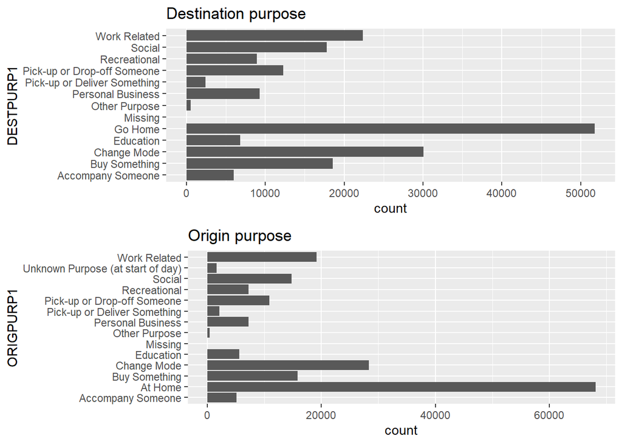

```r
p1 <- ggplot(stops,aes(y = DESTPURP1))+geom_bar()+labs(title="Destination purpose")
p2 <- ggplot(stops,aes(y = ORIGPURP1))+geom_bar()+labs(title="Origin purpose")
grid.arrange(p1, p2)
```

Consistent with the Place findings in the previous section, the most common purpose for both origin and destination is ‘At Home’/‘Go Home’. This is followed by ‘Change Mode’, ‘Work Related’, ‘Buy Something’ and ‘Social’ - these are somewhat more common as destinations than origins.

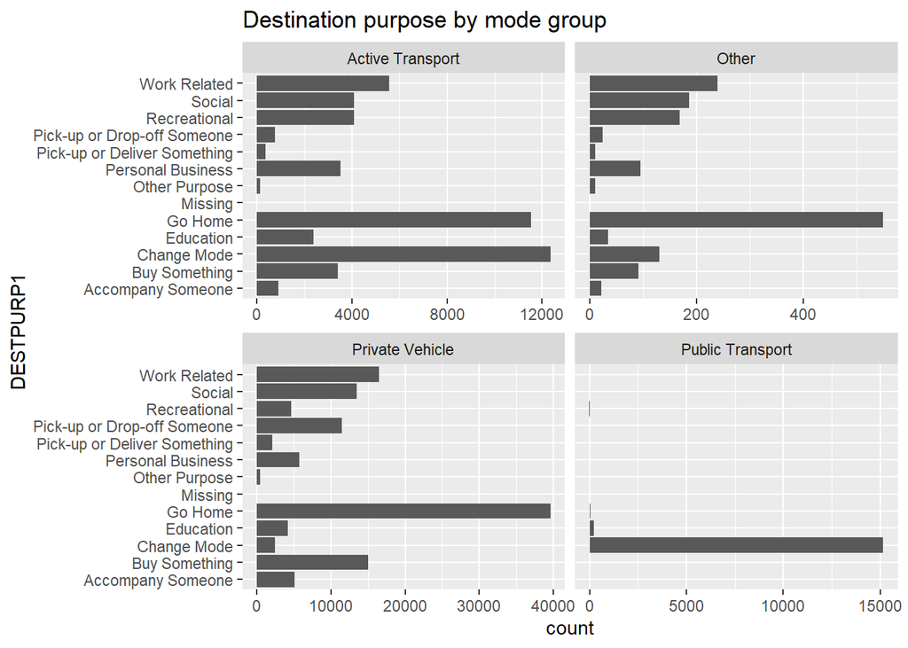

```r
ggplot(stops,aes(y = DESTPURP1))+geom_bar()+facet_wrap(~Mode_grp4,scales="free_x")+labs(title = "Destination purpose by mode group")
```

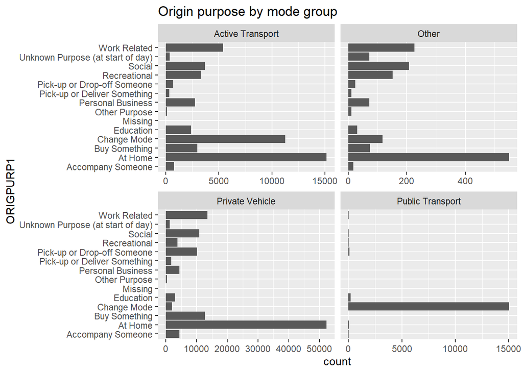

```r
ggplot(stops,aes(y = ORIGPURP1))+geom_bar()+facet_wrap(~Mode_grp4,scales="free_x")+labs(title = "Origin purpose by mode group")
```

Change Mode is almost the only purpose for Public Transport travel, as it is usually necessary to access public transport or complete onward travel by other modes (usually active transport, sometimes private vehicle). The only other non-negligible purpose is Education - schools, universities and other education institutions are probably some of the more likely places to be directly served by public transport to campus without need for additional walking to reach campus.

For active transport the two largest purposes are Home and Change Mode - for origins At Home is larger but for destinations Change mode is larger. This is consistent, as mentioned before, with walking to access public transport.

For private vehicles the most dominant purpose is Home, followed by Work Related and Buy something. For obvious reasons Pick-up or Drop-off Someone is a purpose overwhelmingly accomplished by private vehicle.

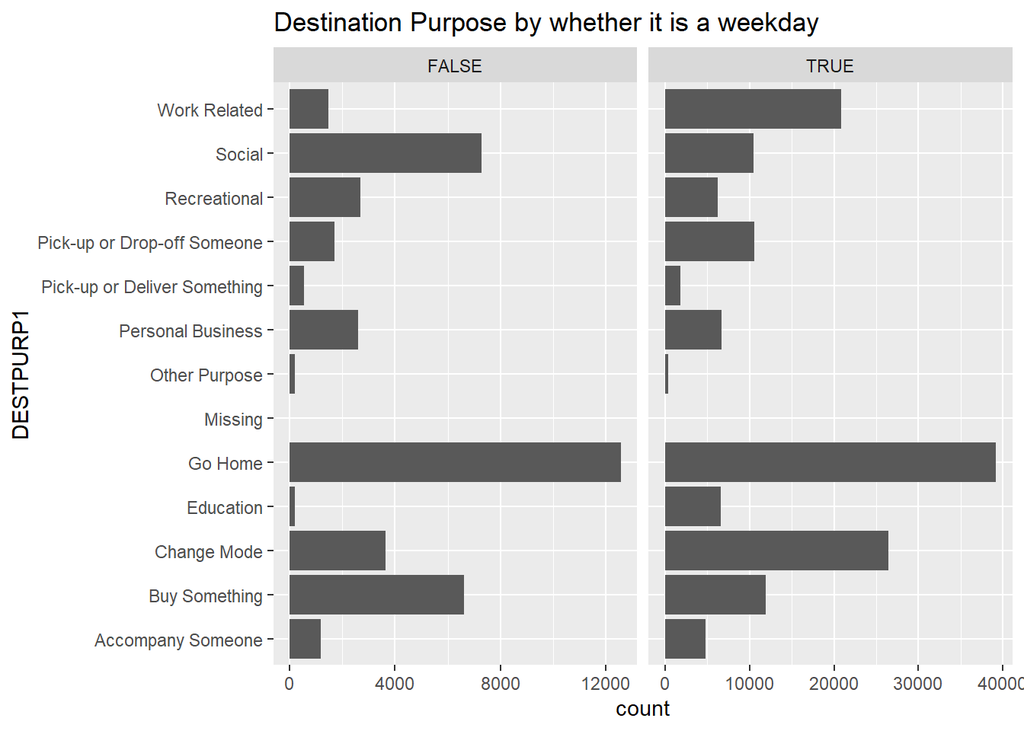

```r
ggplot(stops,aes(y = DESTPURP1))+geom_bar()+facet_wrap(~ISWEEKDAY,scales="free_x")+labs(title="Destination Purpose by whether it is a weekday")
```

On weekdays Work Related, Go Home and Change Mode purposes are dominant, while on weekends Go Home, Social and Buy Something purposes dominate. It is expected that leisure-related purposes are more dominant on weekends.

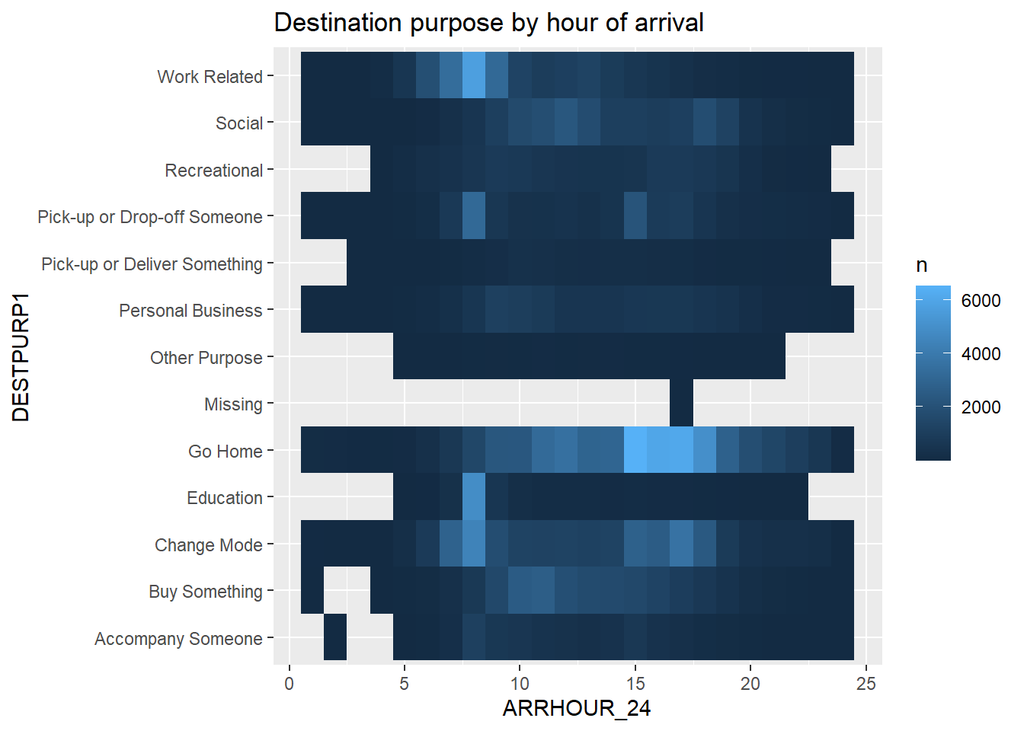

```r
counting <- count(stops, DESTPURP1, ARRHOUR_24)
ggplot(data = counting, mapping = aes(y=DESTPURP1,x=ARRHOUR_24))+geom_tile(mapping = aes(fill=n))+labs(title = "Destination purpose by hour of arrival")
```

Here we can see that arrivals with a Go Home destination purpose peak in the afternoon from about 3 to 6pm, consistent with coming home from work or school. Work related arrivals peak at 8am with a smooth drop off either side, consistent with the 9-to-5 workday with some variation. Education related arrivals also peak at 8am but declines quicker on either side, consistent with the typical school day that school-age students must adhere to - the smaller number of arrivals not at 8am are likely university students. ‘Change mode’ arrivals exhibit a bimodal distribution, with peaks around 7 to 8am and 3 to 6pm likely reflecting interchanges on the way to or from work or education. There are still substantial Change Mode arrivals in the middle of the day, attributable to travel for non-work/education purposes. Buy Something arrivals peak around 10am but are high from about 9am to 4pm, reflecting usual shop opening hours and most shoppers arriving between the commuting peaks. Social travel is relatively stable through out the day but has two slight peaks around 10am to 1pm and again around 7pm, reflecting both late-morning/lunch and evening social gathering habits. ‘Pick-up or drop-off someone’ arrivals as well as ‘Accompany Someone’ arrivals peak at 8am and 3pm, reflective of the standard school day. Recreational and Personal Business is fairly steady from 9am to 7pm.

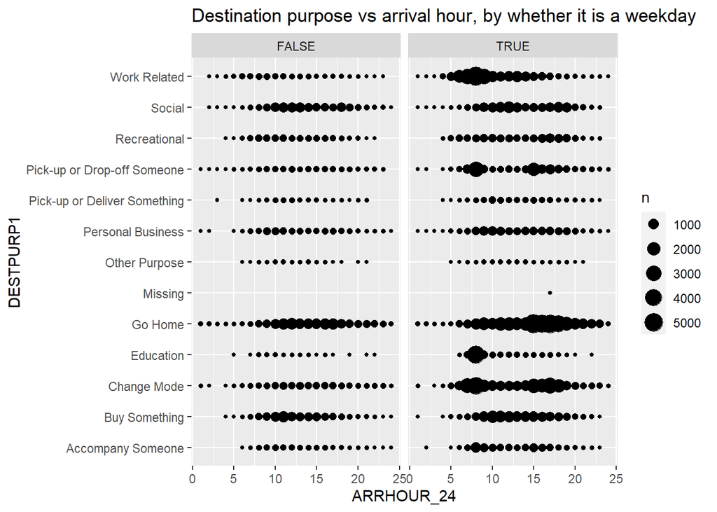

```r
ggplot(data = stops)+geom_count(mapping = aes(y=DESTPURP1,x=ARRHOUR_24))+facet_wrap(~ISWEEKDAY)+labs(title = "Destination purpose vs arrival hour, by whether it is a weekday")
```

Faceting by ISWEEKDAY, education and work trips are negligible on weekends. Change Mode is smaller on weekends and does not have the same bimodal distribution. Buy Something is steady but skews a bit later in the day (shops tend to open later on weekends). Recreational activity has a bimodal distribution on weekdays (9-10am and 4-8pm) but not on weekends, perhaps because work and education commitments on weekdays squeeze recreation to either end of the day.

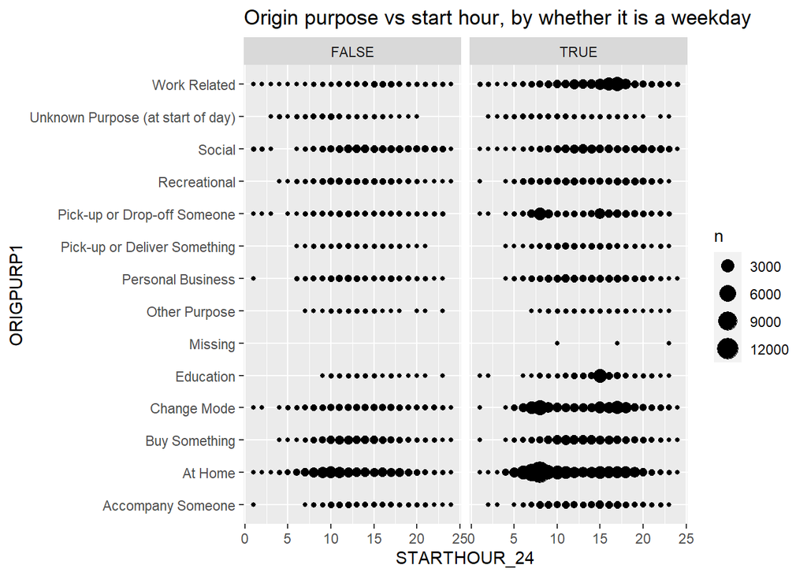

```r
ggplot(data = stops)+geom_count(mapping = aes(y=ORIGPURP1,x=STARTHOUR_24))+facet_wrap(~ISWEEKDAY)+labs(title = "Origin purpose vs start hour, by whether it is a weekday")
```

Looking at the inverse, start hour against origin purpose, we can see the directional weekday peak (unimodal) patterns identified before are reversed - work related origin trips peak 4-5pm, education peak 3pm, at home origin peaks 8am. Other bimodal purposes such as Change Mode and Pick-up or Drop-off, or purposes steady throughout the day, remain similar.

## 6.5 Persons accompanying on trip and in household

As part of data cleaning I replaced the original 9 person columns with two new columns, one reflecting how many additional household members accompanied the traveler on the trip stage, and one of how many household members there are.

```r
table(stops$OTHERPERSONSINHOUSEHOLD)
```

```
##
##     0     1     2     3     4     5     6     7     8     9
##   133 17348 50255 35131 52894 22262  6437  1441   545   323
```

```r
table(stops$PERSONSACCOMPANYING)
```

```
##
##      0      1      2      3      4      5      6      7
## 115422  41759  17557   8771   2586    486    160     28
```

```r
head(stops[stops$OTHERPERSONSINHOUSEHOLD==0,]%>% select(matches(c("PERSON","ID"))))
```

```
##       PERSONSACCOMPANYING OTHERPERSONSINHOUSEHOLD         ï..STOPID
## 35943                   0                       0 Y13H0530302P04S07
## 37120                   0                       0 Y13H0550238P01S09
## 37322                   0                       0 Y13H0550427P02S03
## 37567                   0                       0 Y13H0560118P01S03
## 38837                   0                       0 Y13H0570238P02S06
## 39068                   0                       0 Y13H0570501P01S04
##               PERSID        HHID
## 35943 Y13H0530302P04 Y13H0530302
## 37120 Y13H0550238P01 Y13H0550238
## 37322 Y13H0550427P02 Y13H0550427
## 37567 Y13H0560118P01 Y13H0560118
## 38837 Y13H0570238P02 Y13H0570238
## 39068 Y13H0570501P01 Y13H0570501
```

Some records have two PERSIDs with the same HHID both indicating there are no other persons in the household. This seems contradictory, it could be a data entry error or a deliberate part of how data is encoded to protect privacy/avoid identification.

It is also important to keep in mind that this is data about trip legs, not households. eg. there are 133 trip legs done by someone with nobody else in the household, not 133 households.

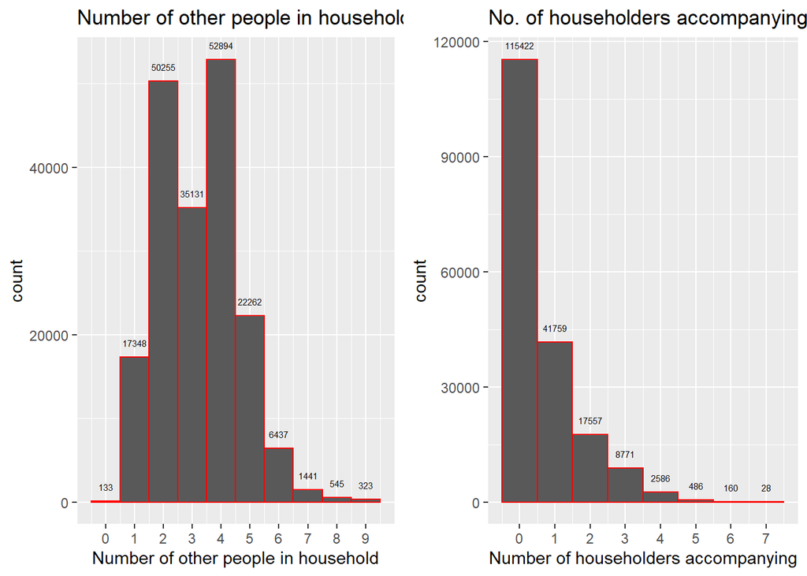

```r
#ggplot(stops,aes(y = OTHERPERSONSINHOUSEHOLD, fill=PERSONSACCOMPANYING))+geom_bar()
p1 <- plot_hist(stops$OTHERPERSONSINHOUSEHOLD,10)+scale_x_continuous(breaks = c(0:9),name="Number of other people in household")+labs(title = "Number of other people in household")
p2 <- plot_hist(stops$PERSONSACCOMPANYING,8)+scale_x_continuous(breaks = c(0:7),name="Number of householders accompanying")+labs(title = "No. of householders accompanying")
grid.arrange(p1, p2,ncol=2)
```

```r
summary(stops$OTHERPERSONSINHOUSEHOLD)
```

```
##    Min. 1st Qu.  Median    Mean 3rd Qu.    Max.
##   0.000   2.000   3.000   3.224   4.000   9.000
```

```r
summary(stops$PERSONSACCOMPANYING)
```

```
##    Min. 1st Qu.  Median    Mean 3rd Qu.    Max.
##  0.0000  0.0000  0.0000  0.6271  1.0000  7.0000
```

Number of other people in household has bimodal peaks at 2 and 4 other people in household, with a median of 3 and mean of 3.224. This suggests most trip legs in this dataset are by households with 3 or 5 members.

The fact that there are only 133 records with no other household members suggests a huge underrepresentation of those living alone and their travel patterns. 2016 census data for Household Composition shows that 23.2% of households in Greather Melbourne are lone person households (https://www.abs.gov.au/census/find-census-data/quickstats/2016/2GMEL#householdcomposition). Furthermore, the average number of people per Melbourne household is 2.7, whereas most trip legs being in households of 3 or 5 suggests overrepresentation of large households. Either that or the phrasing of the survey questions is ambiguous and a value of 2 can actually be interpreted as a two-person household.

Most trip legs in this dataset do not have other household members accompanying. The median number accompanying is 0, with a mean of 0.6271 and upper quartile of 1. The data is right-skewed, with a long tail of a few trip legs with up to 7 accompanying.

It would be interesting to see if certain modes of travel are preferred by certain household sizes or numbers of accompanying householders.

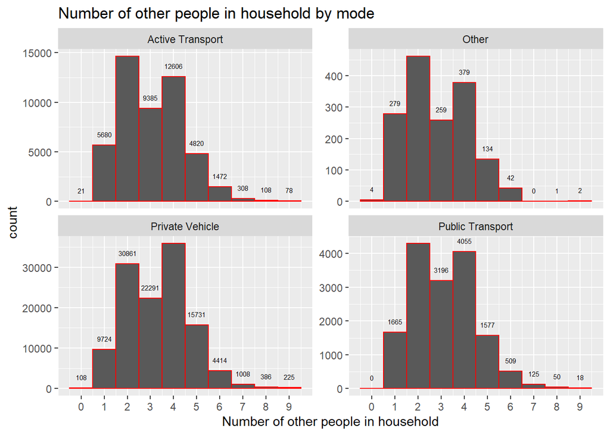

```r
plot_hist(stops$OTHERPERSONSINHOUSEHOLD,10)+scale_x_continuous(breaks = c(0:9),name="Number of other people in household")+labs(title = "Number of other people in household by mode")+facet_wrap(~Mode_grp4,scales="free_y")
```

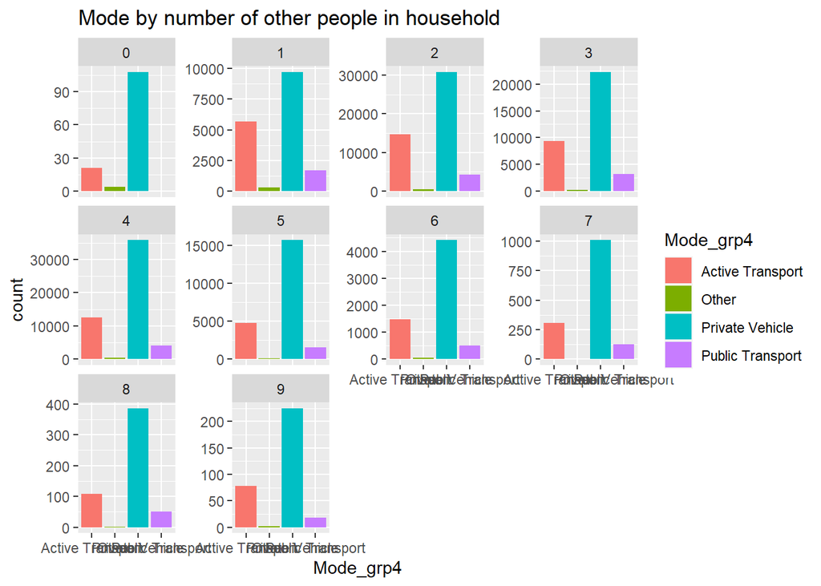

```r
ggplot(stops,aes(x = Mode_grp4, fill = Mode_grp4))+geom_bar()+labs(title = "Mode by number of other people in household")+facet_wrap(~OTHERPERSONSINHOUSEHOLD,scales="free_y")
```

The trend is not totally clear, but it seems like private vehicle usage is higher in households with at least 4 other members. The point may be easier to convey with a table:

```r
HSIZE_MODE <- table(stops$OTHERPERSONSINHOUSEHOLD,stops$Mode_grp4)
cbind(as.data.frame.matrix(HSIZE_MODE)/rowSums(as.data.frame.matrix(HSIZE_MODE))*100,"100%")
```

```
##   Active Transport     Other Private Vehicle Public Transport "100%"
## 0         15.78947 3.0075188        81.20301         0.000000   100%
## 1         32.74153 1.6082546        56.05257         9.597648   100%
## 2         29.12944 0.9193115        61.40882         8.542434   100%
## 3         26.71430 0.7372406        63.45108         9.097378   100%
## 4         23.83257 0.7165274        67.78463         7.666276   100%
## 5         21.65124 0.6019226        70.66301         7.083820   100%
## 6         22.86780 0.6524779        68.57232         7.907410   100%
## 7         21.37405 0.0000000        69.95142         8.674532   100%
## 8         19.81651 0.1834862        70.82569         9.174312   100%
## 9         24.14861 0.6191950        69.65944         5.572755   100%
```

```r
#MODE_HSIZE <- table(stops$Mode_grp4,stops$OTHERPERSONSINHOUSEHOLD)
#cbind(as.data.frame.matrix(MODE_HSIZE)/rowSums(as.data.frame.matrix(MODE_HSIZE))*100,"100%")
```

Even looking at the proportion of each mode at each household size, there is no clear relationship overall. However, private vehicle usage does rise as household size rises from 1 to 5 other householders, and public transport and active transport usage drops somewhat. Outside this range these trends do not hold, however sample size is very small outside the range so it may not matter.

A car’s cost has many fixed components regardless of how many people use (although costs eg. petrol can also increase with increased use), where as public transport fares are mostly per person. So it would be reasonable that up to a point having more people in a household would make private vehicle usage become more economical in a way that doesn’t apply to public transport. Although the trend would be unclear as where several adults are present in a household, sharing cars may be more hassle and time-consuming than owning your own car (hence no more economical than a smaller household) or using public transport. So we would expect to see a more clear correlation between the number of people from the same household undertaking a particular trip, and the use of private vehicles.

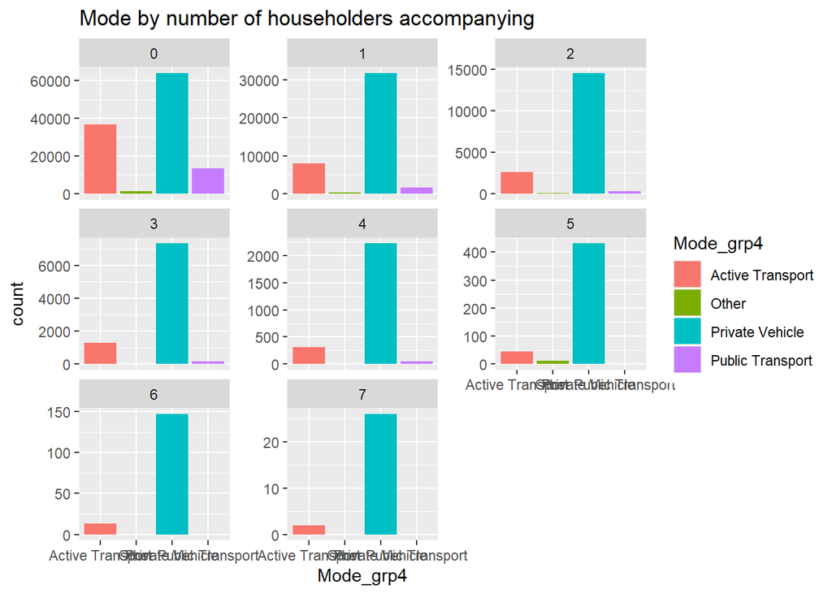

```r
ggplot(stops,aes(x = Mode_grp4, fill = Mode_grp4))+geom_bar()+labs(title = "Mode by number of householders accompanying")+facet_wrap(~PERSONSACCOMPANYING,scales="free_y")
```

```r
ACCOM_MODE <- table(stops$PERSONSACCOMPANYING,stops$Mode_grp4)
cbind(as.data.frame.matrix(ACCOM_MODE)/rowSums(as.data.frame.matrix(ACCOM_MODE))*100,"100%")
```

```
##   Active Transport      Other Private Vehicle Public Transport "100%"
## 0        31.889068 1.09944378        55.47989        11.531597   100%
## 1        19.231782 0.54599009        76.25901         3.963218   100%
## 2        15.008259 0.25061229        82.96406         1.777069   100%
## 3        14.559343 0.10261088        83.50245         1.835595   100%
## 4        11.910286 0.03866976        86.11756         1.933488   100%
## 5         9.053498 2.26337449        88.68313         0.000000   100%
## 6         8.125000 0.00000000        91.87500         0.000000   100%
## 7         7.142857 0.00000000        92.85714         0.000000   100%
```

There is a very clear trend as the number of persons from household accompanying for trip leg increases, for private vehicle usage to increase and public transport and active transport usage to decrease. The trend here is a lot clearer than with the number of persons in the household but not necessarily on the trip, because if they are all making the same trip than in this circumstance they can fully benefit from sharing the cost of running a private vehicle between multiple people.

## 6.6 STOP NO

```r
summary(stops$STOPNO)
```

```
##    Min. 1st Qu.  Median    Mean 3rd Qu.    Max.
##   1.000   1.000   3.000   3.314   4.000  26.000
```

For stop number, the minimum of 1 makes sense, these would logically be the first stop in a journey. The maximum of 26 is surprisingly high, but a trip with 26 stops is not totally inconceivable.

```r
count.over <- sum(stops$STOPNO > 23, na.rm = TRUE)
cat("\nSTOPNO over",count.over, "or ", count.over/length(stops$STOPNO)*100,"%")
```

```
##
## STOPNO over 6 or  0.003212525 %
```

```r
stops[stops$STOPNO > 23,]%>% select("STARTHOUR":"Mode_grp4")
```

```
##        STARTHOUR STARTIME ARRHOUR ARRTIME DURATION DEPHOUR DEPTIME TRAVTIME
## 169810        17     1054      17    1057        5      17    1062        3
## 169811        17     1062      17    1072        0      17    1072       10
## 169812        17     1072      18    1080      999      NA      NA        8
## 169836        17     1054      17    1057        5      17    1062        3
## 169837        17     1062      17    1072        0      17    1072       10
## 169838        17     1072      18    1080      999      NA      NA        8
##        VISTADIST     ORIGLGA        ORIGPLACE1    ORIGPLACE2   ORIGPURP1
## 169810       0.2 Darebin (C) Transport Feature      Bus Stop Change Mode
## 169811       3.9 Darebin (C) Transport Feature Train Station Change Mode
## 169812       1.8 Darebin (C) Transport Feature Train Station Change Mode
## 169836       0.2 Darebin (C) Transport Feature      Bus Stop Change Mode
## 169837       3.9 Darebin (C) Transport Feature Train Station Change Mode
## 169838       1.8 Darebin (C) Transport Feature Train Station Change Mode
##               ORIGPURP2     DESTLGA        DESTPLACE1    DESTPLACE2
```

[output cut: 20 more lines]

All these stages have a mode of travel of walking, train, bus or ute driver. These all took place on weekdays are were all within the local government area of Darebin (C).

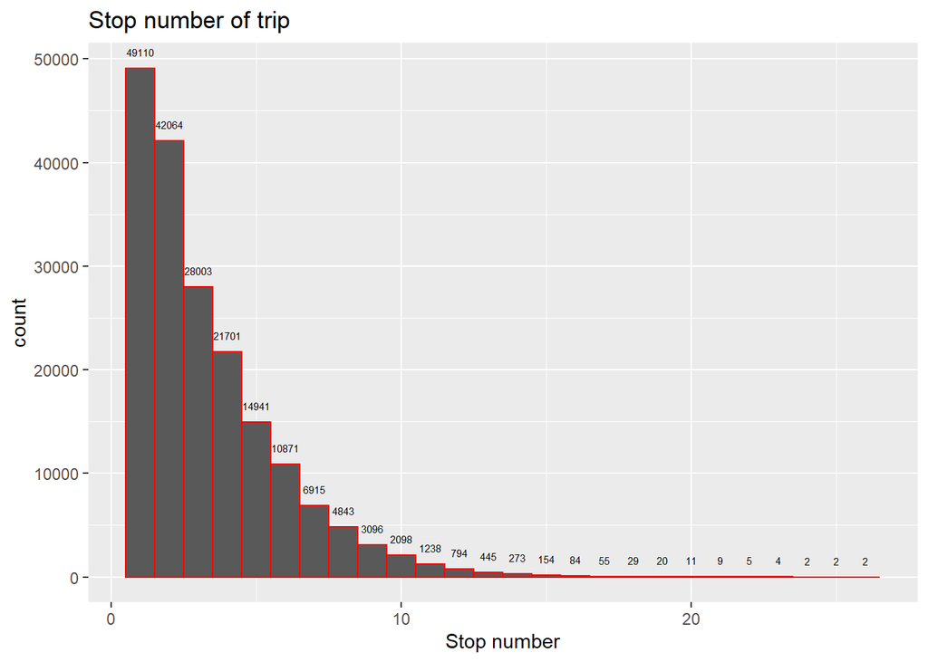

```r
plot_hist(stops$STOPNO,26)+labs(title = "Stop number of trip")+scale_x_continuous(name="Stop number")
```

The right-skew for stop number is inherent to the fact that a high stop number implies previous stages for the trip when all the lower-numbered stops were made.

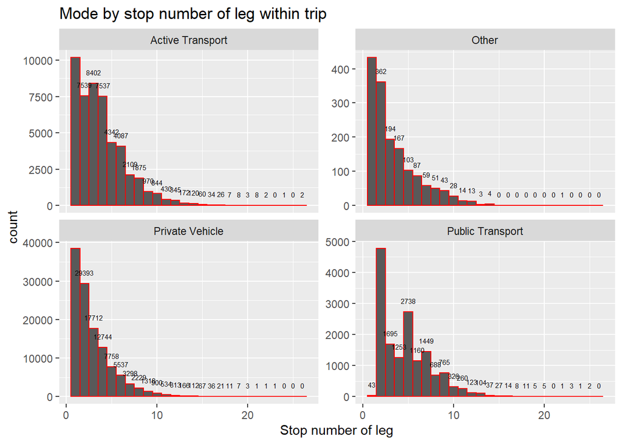

```r
plot_hist(stops$STOPNO,26)+labs(title = "Mode by stop number of leg within trip")+facet_wrap(~Mode_grp4,scales="free_y")+scale_x_continuous(name="Stop number of leg")
```

We can see that private transport has an extreme right-skew with a stop numbers rapidly dropping off, whereas for active transport and public transport is fairly steady even up to 5 or more stops. By nature public transport journeys tend to involve more changing between modes, including by active transport (walking).

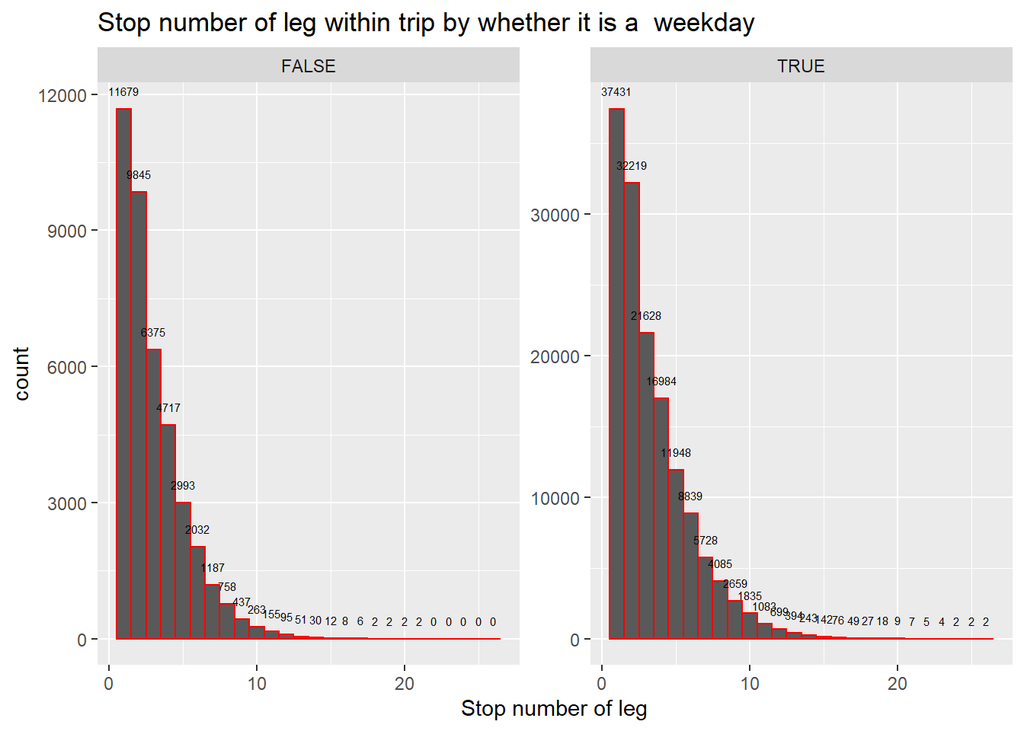

```r
plot_hist(stops$STOPNO,26)+labs(title = "Stop number of leg within trip by whether it is a  weekday")+facet_wrap(~ISWEEKDAY,scales="free_y")+scale_x_continuous(name="Stop number of leg")
```

The distribution of stop number is not affected by whether it is a weekday or weekend.

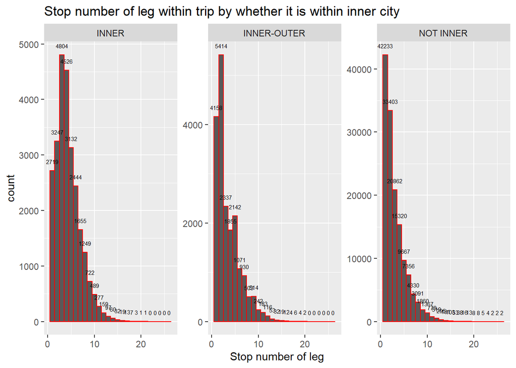

```r
plot_hist(stops$STOPNO,26)+labs(title = "Stop number of leg within trip by whether it is within inner city")+facet_wrap(~INNERCITYTRAVEL,scales="free_y")+scale_x_continuous(name="Stop number of leg")
```